# R语言统计与建模

## 9.2 局部加权回归

### 意义与使用场景

**核心意义**：局部加权回归（LOESS/LOWESS）通过局部拟合来探索变量间的非线性关系，无需指定函数形式。

**举例**：探索年龄与血压的非线性关系

**为什么这种数据适合用局部加权回归？**

首先，年龄与血压的关系可能是非线性的：中年以前血压随年龄增加，老年后可能趋于稳定甚至下降。其次，我们不知道具体的函数形式，不想假设线性或多项式关系。局部加权回归通过局部拟合，能够灵活地探索变量间的非线性关系，是数据探索的有效工具。

**研究目的是什么？**

本研究有三个层次的目的：1. 探索非线性关系：判断年龄与血压是否存在非线性关系；2. 发现转折点：识别血压变化的转折年龄；3. 指导后续建模：根据LOESS曲线选择合适的参数模型。

**可能得到什么样的结果？**

假设局部加权回归显示：血压随年龄增加，但在60岁后增速放缓。

1. 非线性关系：LOESS曲线明显非线性，线性回归假设不合适。
2. 转折点：约60岁处曲线斜率变化，血压增速放缓。
3. 分段特征：40岁前血压增长较快（每年0.5mmHg），40-60岁增长中等（每年0.3mmHg），60岁后增长缓慢（每年0.1mmHg）。
4. 建模建议：建议使用分段线性模型或样条回归进行正式分析。

**需要注意什么？**

LOESS的结果依赖于span参数的选择：span过小导致过拟合，span过大导致欠拟合。建议尝试多个span值，选择既能捕捉趋势又不过度波动的曲线。LOESS主要用于探索性分析，正式建模建议使用样条回归或GAM。边界区域的估计不稳定，需谨慎解释。

### 数学基础

**LOESS/LOWESS**：

局部加权散点图平滑。

$$\hat{y}(x_0) = \sum_{i=1}^{n} w_i(x_0)
y_i$$

**权重函数**：

使用核函数计算权重，距离$x_0$越近的点权重越大。

**参数说明**： - span：邻域比例（通常0.3-0.8） - degree：局部多项式阶数（1或2）

### 代码实现

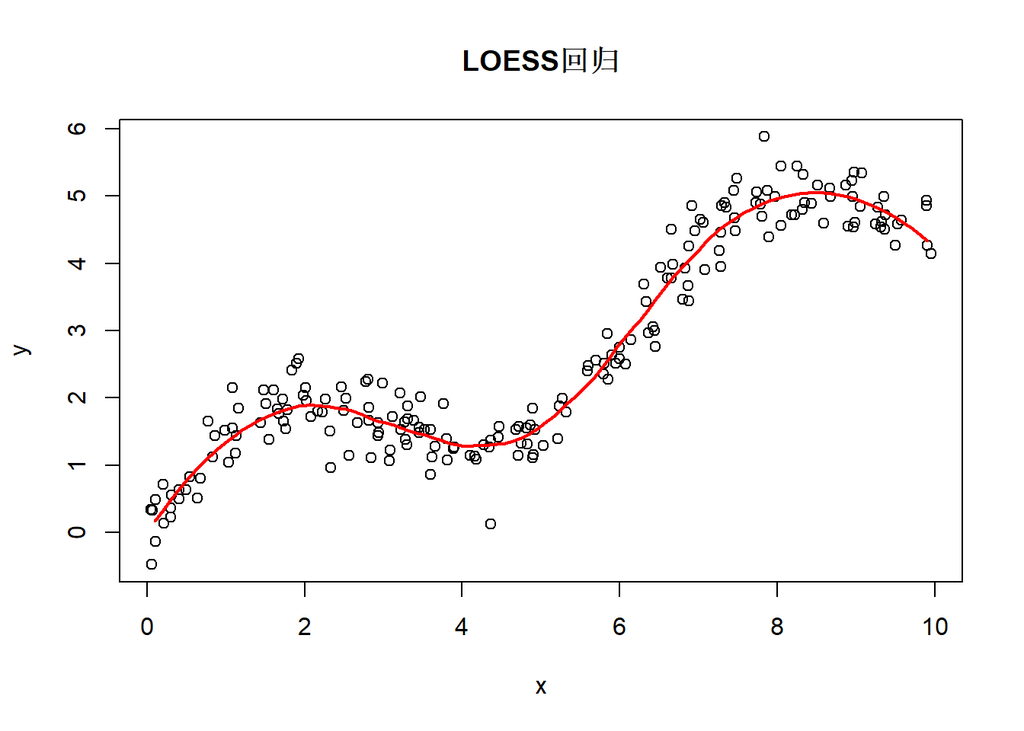

```r
# 模拟非线性关系数据
set.seed(777)
n_loess <- 200
x_loess <- runif(n_loess, 0, 10)
y_loess <- sin(x_loess) + 0.5 * x_loess + rnorm(n_loess, 0, 0.3)

loess_data <- data.frame(x = x_loess, y = y_loess)

# LOESS回归
loess_fit <- loess(y ~ x, data = loess_data, span = 0.5)

# 预测
x_pred <- seq(0, 10, length.out = 100)
y_pred <- predict(loess_fit, newdata = data.frame(x = x_pred))

# 绘制拟合曲线
plot(loess_data$x, loess_data$y, main = "LOESS回归", xlab = "x", ylab = "y")
lines(x_pred, y_pred, col = "red", lwd = 2)
```

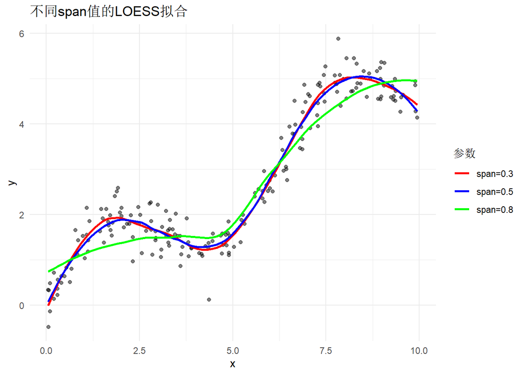

```r
# 比较不同span值
ggplot2::ggplot(loess_data, ggplot2::aes(x = x, y = y)) +
  ggplot2::geom_point(alpha = 0.5) +
  ggplot2::geom_smooth(method = "loess", span = 0.3, ggplot2::aes(color = "span=0.3"), se = FALSE) +
  ggplot2::geom_smooth(method = "loess", span = 0.5, ggplot2::aes(color = "span=0.5"), se = FALSE) +
  ggplot2::geom_smooth(method = "loess", span = 0.8, ggplot2::aes(color = "span=0.8"), se = FALSE) +
  ggplot2::scale_color_manual(values = c("span=0.3" = "red", "span=0.5" = "blue", "span=0.8" = "green")) +
  ggplot2::labs(title = "不同span值的LOESS拟合", color = "参数") +
  ggplot2::theme_minimal()
```

## 9.3 样条回归

### 意义与使用场景

**核心意义**：样条回归使用分段多项式拟合非线性关系，在节点处保持连续，灵活且可解释。

**举例**：药物剂量-效应曲线拟合

**为什么这种数据适合用样条回归？**

首先，药物剂量与效应的关系可能是非线性的：低剂量时效应增长快，高剂量时趋于饱和。其次，我们需要一个灵活但可解释的模型，能够捕捉非线性特征同时控制复杂度。样条回归使用分段多项式，在节点处保持连续，能够灵活拟合非线性关系，同时通过自由度控制复杂度。

**研究目的是什么？**

本研究有三个层次的目的：1. 拟合剂量-效应曲线：估计药物剂量与效应的非线性关系；2. 估计有效剂量：计算ED50（半数有效剂量）等关键参数；3. 比较模型：通过AIC比较不同自由度的样条模型。

**可能得到什么样的结果？**

假设样条回归显示：使用5个自由度的自然样条，AIC=1250，ED50=50mg。

1. 剂量-效应曲线：低剂量（0-30mg）效应增长快，中剂量（30-70mg）增长放缓，高剂量（>70mg）趋于饱和。
2. 有效剂量：ED50=50mg，ED90=85mg，为临床用药提供参考。
3. 非线性检验：非线性项的F检验p<0.001，剂量-效应关系显著非线性。
4. 模型比较：5自由度样条比3自由度和7自由度样条AIC更低，拟合最优。

**需要注意什么？**

样条回归的结果依赖于节点数量和位置的选择。自由度越高，拟合越灵活但可能过拟合；自由度越低，拟合越平滑但可能欠拟合。建议通过AIC或交叉验证选择最优自由度。自然样条在边界外线性延伸，比B样条更稳定。惩罚样条（P-spline）通过惩罚项自动控制平滑度。

### 数学基础

**B样条**：

分段多项式，在节点处连续。

$$f(x) = \sum_{j=1}^{k} \beta_j
B_j(x)$$

**自然样条**：

在边界外线性延伸，减少边界效应。

**惩罚样条（P-spline）**：

添加惩罚项控制平滑度：
$$\min
\sum_{i=1}^{n}(y_i - f(x_i))^2 + \lambda \int (f''(x))^2
dx$$

### 代码实现

```r
# 使用样条回归
library(splines)

# B样条回归
bs_fit <- lm(y ~ bs(x, df = 5), data = loess_data)
summary(bs_fit)
```

```
##
## Call:
## lm(formula = y ~ bs(x, df = 5), data = loess_data)
##
## Residuals:
##      Min       1Q   Median       3Q      Max
## -1.34810 -0.26004 -0.06715  0.23288  1.05147
##
## Coefficients:
##                Estimate Std. Error t value Pr(>|t|)
## (Intercept)     -0.2885     0.1321  -2.184   0.0301 *
## bs(x, df = 5)1   3.5073     0.2586  13.563   <2e-16 ***
## bs(x, df = 5)2   0.2024     0.1866   1.085   0.2794
## bs(x, df = 5)3   3.6520     0.2469  14.793   <2e-16 ***
## bs(x, df = 5)4   6.5791     0.2095  31.399   <2e-16 ***
## bs(x, df = 5)5   4.2491     0.2180  19.490   <2e-16 ***
## ---
## Signif. codes:  0 '***' 0.001 '**' 0.01 '*' 0.05 '.' 0.1 ' ' 1
##
## Residual standard error: 0.3959 on 194 degrees of freedom
## Multiple R-squared:  0.9396, Adjusted R-squared:  0.938
## F-statistic: 603.3 on 5 and 194 DF,  p-value: < 2.2e-16
```

```r
# 自然样条回归
ns_fit <- lm(y ~ ns(x, df = 5), data = loess_data)
summary(ns_fit)
```

```
##
## Call:
## lm(formula = y ~ ns(x, df = 5), data = loess_data)
##
## Residuals:
##      Min       1Q   Median       3Q      Max
## -1.16894 -0.21536  0.00389  0.22757  0.89189
##
## Coefficients:
##                Estimate Std. Error t value Pr(>|t|)
## (Intercept)     0.08711    0.09829   0.886    0.377
## ns(x, df = 5)1  0.56087    0.13206   4.247 3.36e-05 ***
## ns(x, df = 5)2  1.97014    0.16906  11.654  < 2e-16 ***
## ns(x, df = 5)3  5.02433    0.13218  38.012  < 2e-16 ***
## ns(x, df = 5)4  7.01163    0.24794  28.279  < 2e-16 ***
## ns(x, df = 5)5  2.71527    0.12284  22.103  < 2e-16 ***
## ---
## Signif. codes:  0 '***' 0.001 '**' 0.01 '*' 0.05 '.' 0.1 ' ' 1
##
## Residual standard error: 0.3409 on 194 degrees of freedom
## Multiple R-squared:  0.9552, Adjusted R-squared:  0.9541
## F-statistic: 827.4 on 5 and 194 DF,  p-value: < 2.2e-16
```

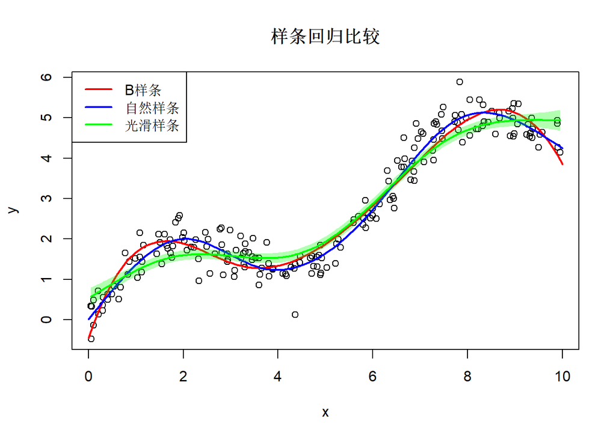

```r
# 光滑样条
smooth_fit <- smooth.spline(x_loess, y_loess, df = 5)

# 绘制比较
plot(loess_data$x, loess_data$y, main = "样条回归比较", xlab = "x", ylab = "y")
lines(x_pred, predict(bs_fit, newdata = data.frame(x = x_pred)), col = "red", lwd = 2)
lines(x_pred, predict(ns_fit, newdata = data.frame(x = x_pred)), col = "blue", lwd = 2)
lines(smooth_fit, col = "green", lwd = 2)
legend("topleft", legend = c("B样条", "自然样条", "光滑样条"),
       col = c("red", "blue", "green"), lty = 1, lwd = 2)
```

```r
# 交叉验证选择自由度
smooth_cv <- smooth.spline(x_loess, y_loess, cv = TRUE)
cat(sprintf("\n交叉验证选择的自由度: %.1f\n", smooth_cv$df))
```

```
##
## 交叉验证选择的自由度: 9.4
```

## 9.4 广义加性模型

### 意义与使用场景

**核心意义**：广义加性模型（GAM）将加性模型与广义线性模型结合，每个预测变量用光滑函数拟合，灵活且可解释。

**举例**：分析多个环境因素对健康的非线性影响

**为什么这种数据适合用广义加性模型？**

首先，健康结果受多个环境因素影响（如PM2.5、温度、湿度），这些因素的效应可能是非线性的。其次，我们需要同时处理多个预测变量的非线性效应，同时保持模型的可解释性。广义加性模型能够为每个预测变量拟合光滑函数，自动选择光滑程度，同时保持加性结构的可解释性。

**研究目的是什么？**

本研究有三个层次的目的：1. 拟合非线性效应：估计各环境因素对健康的非线性影响；2. 控制混杂：在控制其他因素后，估计每个因素的独立效应；3. 比较效应强度：判断哪个环境因素对健康的影响最大。

**可能得到什么样的结果？**

假设广义加性模型显示：PM2.5效应非线性（EDF=4.5），温度效应非线性（EDF=3.2）。

1. PM2.5效应：PM2.5对健康的影响呈阈值效应：低于50μg/m³影响较小，高于50μg/m³影响急剧增加。
2. 温度效应：温度对健康的影响呈U型：极低和极高温度都有害，最适温度约20℃。
3. 效应比较：PM2.5的效应强度（F=25.3）大于温度（F=15.6），是更重要的环境因素。
4. 模型拟合：调整R²=0.45，GAM比线性模型（调整R²=0.32）拟合更好。

**需要注意什么？**

GAM的光滑函数有效自由度（EDF）反映非线性程度：EDF=1表示线性，EDF>1表示非线性。光滑参数通过GCV或REML自动选择，避免过拟合。GAM假设加性结构，不捕捉变量间的交互作用，可通过添加交互项解决。模型诊断需检查残差是否满足分布假设。

### 数学基础

**GAM模型**：

$$g(E[Y]) = \beta_0 + f_1(X_1) + f_2(X_2)
+ \cdots + f_p(X_p)$$

**参数说明**： - $g(\cdot)$：链接函数 - $f_j(\cdot)$：光滑函数（如样条）

**光滑参数选择**：

使用GCV（广义交叉验证）或REML选择。

### 代码实现

```r
# 模拟GAM数据
set.seed(888)
n_gam <- 300

x1_gam <- runif(n_gam, 0, 10)
x2_gam <- runif(n_gam, 0, 10)
y_gam <- sin(x1_gam) + 0.5 * x2_gam^2 + rnorm(n_gam, 0, 1)

gam_data <- data.frame(x1 = x1_gam, x2 = x2_gam, y = y_gam)

# 拟合GAM模型
library(mgcv)
gam_fit <- mgcv::gam(y ~ s(x1) + s(x2), data = gam_data)
summary(gam_fit)
```

```
##
## Family: gaussian
## Link function: identity
##
## Formula:
## y ~ s(x1) + s(x2)
##
## Parametric coefficients:
##             Estimate Std. Error t value Pr(>|t|)
## (Intercept)  16.3745     0.0539   303.8   <2e-16 ***
## ---
## Signif. codes:  0 '***' 0.001 '**' 0.01 '*' 0.05 '.' 0.1 ' ' 1
##
## Approximate significance of smooth terms:
##         edf Ref.df        F p-value
## s(x1) 6.415  7.569    20.07  <2e-16 ***
## s(x2) 5.898  7.065 10073.53  <2e-16 ***
## ---
## Signif. codes:  0 '***' 0.001 '**' 0.01 '*' 0.05 '.' 0.1 ' ' 1
##
## R-sq.(adj) =  0.996   Deviance explained = 99.6%
## GCV = 0.91212  Scale est. = 0.87165   n = 300
```

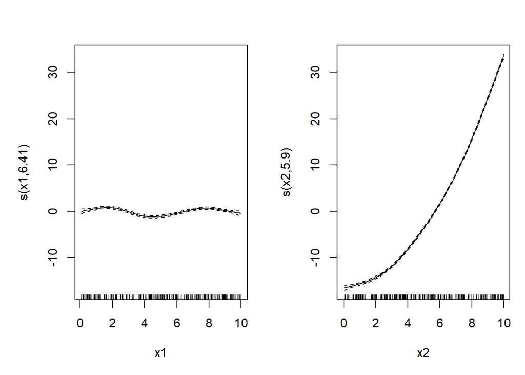

```r
# 查看光滑函数
par(mfrow = c(1, 2))
plot(gam_fit, pages = 1)
```

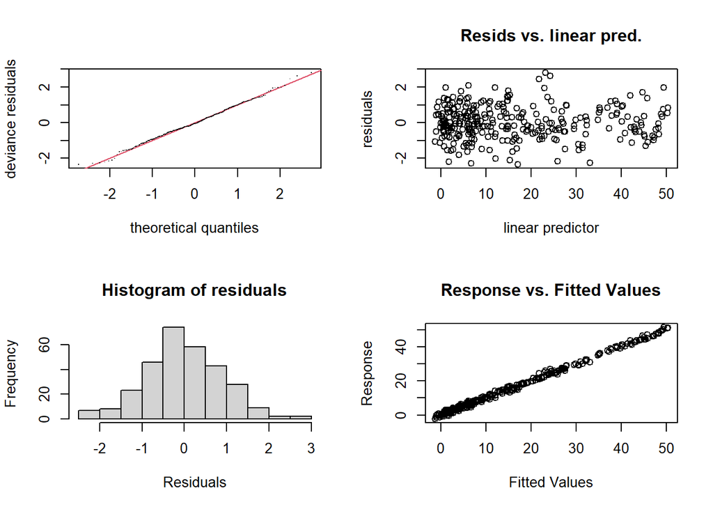

```
##
## Method: GCV   Optimizer: magic
## Smoothing parameter selection converged after 8 iterations.
## The RMS GCV score gradient at convergence was 1.39935e-06 .
## The Hessian was positive definite.
## Model rank =  19 / 19
##
## Basis dimension (k) checking results. Low p-value (k-index<1) may
## indicate that k is too low, especially if edf is close to k'.
##
##         k'  edf k-index p-value
## s(x1) 9.00 6.41    1.02   0.635
## s(x2) 9.00 5.90    0.92   0.065 .
## ---
## Signif. codes:  0 '***' 0.001 '**' 0.01 '*' 0.05 '.' 0.1 ' ' 1
```

```r
par(mfrow = c(1, 1))

# 检查模型
gam.check(gam_fit)
```

```r
# 比较不同基函数维度
gam_fit_k10 <- mgcv::gam(y ~ s(x1, k = 10) + s(x2, k = 10), data = gam_data)
gam_fit_k20 <- mgcv::gam(y ~ s(x1, k = 20) + s(x2, k = 20), data = gam_data)

cat("\n========== GAM模型比较 ==========\n")
```

```
##
## ========== GAM模型比较 ==========
```

```r
cat(sprintf("默认k AIC: %.2f\n", AIC(gam_fit)))
```

```
## 默认k AIC: 825.16
```

```r
cat(sprintf("k=10 AIC: %.2f\n", AIC(gam_fit_k10)))
```

```
## k=10 AIC: 825.16
```

```r
cat(sprintf("k=20 AIC: %.2f\n", AIC(gam_fit_k20)))
```

```
## k=20 AIC: 822.41
```

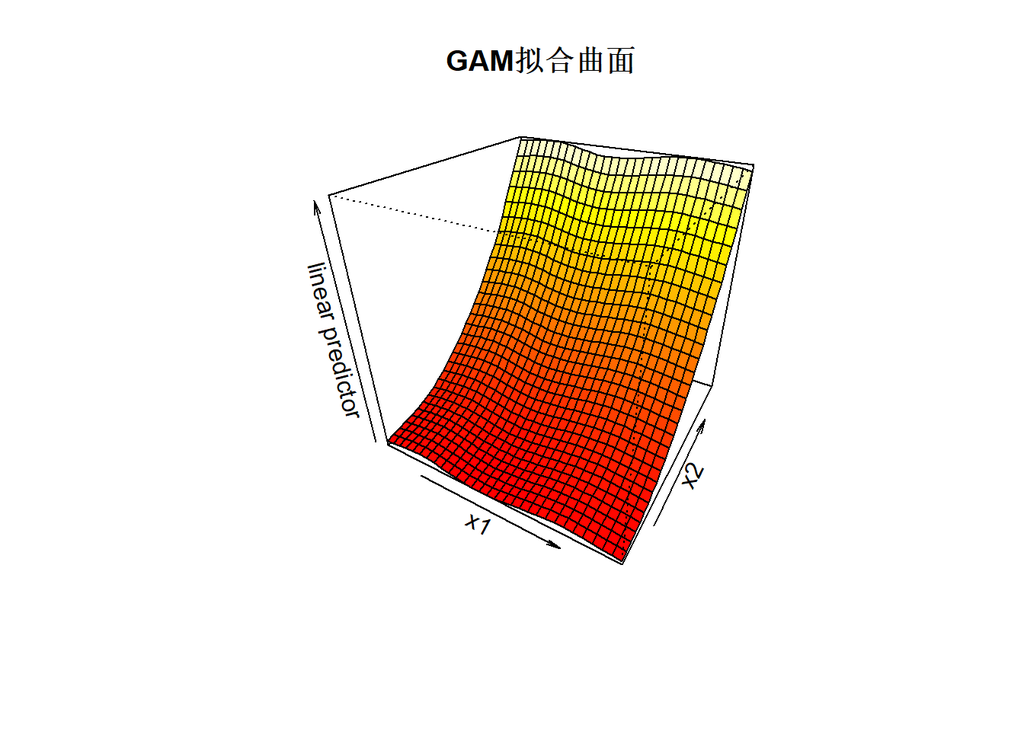

```r
# 可视化拟合曲面
vis.gam(gam_fit, theta = 30, phi = 30, main = "GAM拟合曲面")
```

## 第九章小结

### 核心知识点总结

| 主题 | 核心内容 | 关键函数 |
| --- | --- | --- |
| 核密度估计 | 非参数密度估计 | `density()` |
| LOESS | 局部加权回归 | `loess()` |
| B样条 | 分段多项式 | `bs()` |
| 自然样条 | 边界线性延伸 | `ns()` |
| 光滑样条 | 惩罚平滑 | `smooth.spline()` |
| GAM | 加性模型 | `mgcv::gam()` |

# 第十章：计量经济学专门方法

计量经济学方法在医学研究中广泛应用于因果推断、政策评估等领域。本章将系统讲解工具变量、断点回归、双重差分、倾向得分匹配等方法。

## 10.1 工具变量法

### 意义与使用场景

**核心意义**：工具变量法用于解决内生性问题，当解释变量与误差项相关时，通过工具变量获得一致的估计。

**举例**：使用医生处方偏好作为药物使用的工具变量

**为什么这种数据适合用工具变量法？**

首先，药物使用可能存在内生性：选择用药的患者可能与未用药患者在不可观测因素上存在差异（如健康意识、疾病严重程度）。其次，我们有一个有效的工具变量：医生的处方偏好（与患者特征无关，但影响患者是否用药）。工具变量法能够利用工具变量的外生变异，获得药物效应的一致估计。

**研究目的是什么？**

本研究有三个层次的目的：1. 解决内生性：处理药物使用与误差项相关导致的内生性问题；2. 估计因果效应：获得药物使用对健康结果的因果效应估计；3. 检验工具变量：验证工具变量的相关性和外生性。

**可能得到什么样的结果？**

假设工具变量分析显示：2SLS估计β=0.25（p=0.02），OLS估计β=0.15（p=0.10）。

1. 内生性检验：Durbin-Wu-Hausman检验p=0.03，拒绝外生性假设，OLS估计有偏。
2. 第一阶段：医生处方偏好与药物使用显著相关（F=35.6），工具变量相关性强。
3. 因果效应：2SLS估计药物效应β=0.25，比OLS估计（β=0.15）更大，说明OLS低估了药物效应。
4. 外生性检验：Sargan检验p=0.45，不能拒绝工具变量外生性假设。

**需要注意什么？**

工具变量需满足两个条件：相关性（与内生变量强相关，第一阶段F>10）和外生性（与误差项不相关）。弱工具变量会导致估计不准确，需检验第一阶段F统计量。外生性无法直接检验，需基于理论和背景知识判断。工具变量估计是局部平均处理效应（LATE），仅对”依从者”有效。

### 数学基础

**内生性问题**：

当$Cov(X, \varepsilon) \neq 0$时，OLS估计有偏。

**工具变量（IV）条件**：

1. **相关性**：$Cov(Z, X) \neq 0$
2. **外生性**：$Cov(Z, \varepsilon) = 0$

**两阶段最小二乘（2SLS）**：

第一阶段：$\hat{X} = \hat{\pi}_0 + \hat{\pi}_1 Z$ 第二阶段：$\hat{Y} = \hat{\beta}_0 + \hat{\beta}_1 \hat{X}$

**弱工具变量检验**：

第一阶段F统计量 > 10表示工具变量足够强。

### 代码实现

```r
# 模拟IV数据
set.seed(1111)
n_iv <- 500

# 工具变量
z <- rnorm(n_iv)

# 内生变量（与误差相关）
epsilon <- rnorm(n_iv)
x <- 0.5 * z + epsilon + rnorm(n_iv, 0, 0.5)

# 因变量
y <- 2 + 1.5 * x + epsilon + rnorm(n_iv, 0, 1)

iv_data <- data.frame(y = y, x = x, z = z)

# OLS估计（有偏）
ols_model <- lm(y ~ x, data = iv_data)
cat("========== OLS估计（有偏） ==========\n")
```

```
## ========== OLS估计（有偏） ==========
```

```r
print(coef(ols_model))
```

```
## (Intercept)           x
##    1.993248    2.158038
```

```r
# 2SLS估计
library(AER)
iv_model <- AER::ivreg(y ~ x | z, data = iv_data)
summary(iv_model, diagnostics = TRUE)
```

```
##
## Call:
## AER::ivreg(formula = y ~ x | z, data = iv_data)
##
## Residuals:
##     Min      1Q  Median      3Q     Max
## -4.0255 -1.0088 -0.0434  1.0222  4.7738
##
## Coefficients:
##             Estimate Std. Error t value Pr(>|t|)
## (Intercept)  1.90249    0.06934  27.439   <2e-16 ***
## x            1.33331    0.14226   9.372   <2e-16 ***
##
## Diagnostic tests:
##                  df1 df2 statistic p-value
## Weak instruments   1 498     97.79  <2e-16 ***
## Wu-Hausman         1 497     78.97  <2e-16 ***
## Sargan             0  NA        NA      NA
## ---
## Signif. codes:  0 '***' 0.001 '**' 0.01 '*' 0.05 '.' 0.1 ' ' 1
##
## Residual standard error: 1.51 on 498 degrees of freedom
## Multiple R-Squared: 0.7062,  Adjusted R-squared: 0.7056
## Wald test: 87.84 on 1 and 498 DF,  p-value: < 2.2e-16
```

```r
# 第一阶段回归
first_stage <- lm(x ~ z, data = iv_data)
cat("\n========== 第一阶段F统计量 ==========\n")
```

```
##
## ========== 第一阶段F统计量 ==========
```

```r
f_stat <- summary(first_stage)$fstatistic
cat(sprintf("F = %.2f (> 10表示强工具变量)\n", f_stat[1]))
```

```
## F = 97.79 (> 10表示强工具变量)
```

```r
# 弱工具变量检验
cat("\n========== 弱工具变量检验 ==========\n")
```

```
##
## ========== 弱工具变量检验 ==========
```

```r
print(summary(iv_model, diagnostics = TRUE)$diagnostics)
```

```
##                  df1 df2 statistic      p-value
## Weak instruments   1 498  97.78914 3.574747e-21
## Wu-Hausman         1 497  78.96734 1.162513e-17
## Sargan             0  NA        NA           NA
```

## 10.2 断点回归设计

### 意义与使用场景

**核心意义**：断点回归设计（RDD）利用政策实施的临界点进行因果推断，是准实验方法中最接近随机对照试验的设计。

**举例**：评估医保政策（年龄≥65岁获得补贴）的健康效应

**为什么这种数据适合用断点回归设计？**

首先，医保补贴政策有明确的年龄门槛（65岁），形成自然的临界点。其次，在临界点附近，年龄略小于65岁和略大于65岁的人群在可观测和不可观测特征上应该相似（局部随机化假设）。断点回归设计利用这一临界点，比较临界点两侧的结果差异，估计政策的因果效应。

**研究目的是什么？**

本研究有三个层次的目的：1. 估计政策效应：计算医保补贴对医疗支出或健康结果的因果效应；2. 检验局部随机化：验证临界点附近人群的特征是否平衡；3. 敏感性分析：检验结果对带宽选择的敏感性。

**可能得到什么样的结果？**

假设断点回归分析显示：在65岁临界点处，医疗支出下降500元（p<0.001）。

1. 处理效应：医保补贴使医疗支出下降500元，效应显著。
2. 局部随机化：临界点附近人群的年龄、性别、收入等特征平衡，支持局部随机化假设。
3. 带宽敏感性：在不同带宽（5岁、10岁）下结果稳健。
4. 平滑性检验：结果变量在临界点处存在跳跃，支持断点存在。

**需要注意什么？**

断点回归的核心假设是临界点附近个体特征的连续性。需检验临界点附近人群的特征是否平衡，运行变量的密度是否连续（无操纵）。带宽选择影响估计精度和偏差：带宽越小偏差越小但方差越大。建议使用最优带宽选择方法（如IK、CCT）并进行敏感性分析。

### 数学基础

**断点回归（RDD）**：

利用政策实施的临界点进行因果推断。

**清晰断点**：

处理状态在临界点处完全确定：
$$D_i =
\mathbf{1}(X_i \geq c)$$

**模糊断点**：

处理概率在临界点处跳跃。

**估计量**：

$$\tau_{RD} = \lim_{x \downarrow c}
E[Y|X=x] - \lim_{x \uparrow c} E[Y|X=x]$$

### 代码实现

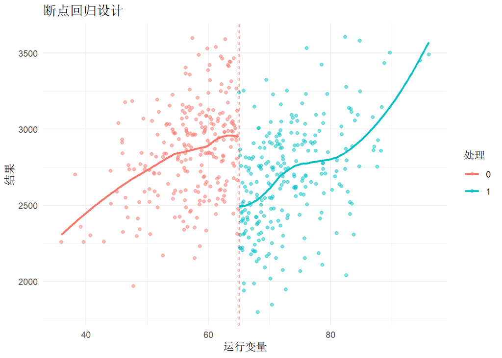

```r
# 模拟RDD数据
set.seed(2222)
n_rdd <- 500

# 运行变量（如年龄）
x_rdd <- rnorm(n_rdd, 65, 10)

# 处理：年龄>=65岁获得补贴
treatment <- as.integer(x_rdd >= 65)

# 结果：医疗支出（处理效应为-500）
y_rdd <- 3000 - 500 * treatment + 20 * (x_rdd - 65) +
         10 * (x_rdd - 65)^2 / 100 + rnorm(n_rdd, 0, 300)

rdd_data <- data.frame(x = x_rdd, treatment = treatment, y = y_rdd)

# 可视化断点
ggplot2::ggplot(rdd_data, ggplot2::aes(x = x, y = y, color = factor(treatment))) +
  ggplot2::geom_point(alpha = 0.5) +
  ggplot2::geom_vline(xintercept = 65, linetype = "dashed", color = "red") +
  ggplot2::geom_smooth(data = subset(rdd_data, x < 65), method = "loess", se = FALSE) +
  ggplot2::geom_smooth(data = subset(rdd_data, x >= 65), method = "loess", se = FALSE) +
  ggplot2::labs(title = "断点回归设计", x = "运行变量", y = "结果", color = "处理") +
  ggplot2::theme_minimal()
```

```r
# 使用rdrobust包
library(rdrobust)
rdd_result <- rdrobust::rdrobust(y_rdd, x_rdd, c = 65)
summary(rdd_result)
```

```
## Sharp RD estimates using local polynomial regression.
##
## Number of Obs.                  500
## BW type                       mserd
## Kernel                   Triangular
## VCE method                       NN
##
## Number of Obs.                  247          253
## Eff. Number of Obs.             124          131
## Order est. (p)                    1            1
## Order bias  (q)                   2            2
## BW est. (h)                   6.954        6.954
## BW bias (b)                  11.580       11.580
## rho (h/b)                     0.601        0.601
## Unique Obs.                     247          253
##
## =====================================================================
##                    Point    Robust Inference
##                 Estimate         z     P>|z|      [ 95% C.I. ]
## ---------------------------------------------------------------------
##      RD Effect  -484.482    -4.743     0.000  [-656.350 , -272.509]
## =====================================================================
```

```r
# 带宽敏感性分析
rdbwselect(y_rdd, x_rdd, c = 65)
```

```
## Call: rdbwselect
##
## Number of Obs.                  500
## BW type                       mserd
## Kernel                   Triangular
## VCE method                       NN
##
## Number of Obs.                  247          253
## Order est. (p)                    1            1
## Order bias  (q)                   2            2
## Unique Obs.                     247          253
```

## 10.3 双重差分法

### 意义与使用场景

**核心意义**：双重差分法（DID）通过比较处理组和对照组在政策实施前后的变化差异，估计政策效应。

**举例**：评估医保政策改革的健康效应

**为什么这种数据适合用双重差分法？**

首先，医保政策改革在某个时间点实施，形成自然实验。其次，我们有处理组（受政策影响的地区）和对照组（不受影响的地区）在政策前后的数据。双重差分法通过比较两组在政策前后的变化差异，消除组间固有差异和时间趋势，估计政策的因果效应。

**研究目的是什么？**

本研究有三个层次的目的：1. 估计政策效应：计算医保改革对医疗支出或健康结果的因果效应；2. 检验平行趋势：验证处理组和对照组在政策前是否有相同的趋势；3. 控制混杂：消除组间差异和时间趋势的影响。

**可能得到什么样的结果？**

假设双重差分分析显示：DID效应=15（p=0.02），平行趋势假设成立。

1. 处理效应：医保改革使处理组的健康结果提高15个单位，效应显著。
2. 平行趋势检验：政策前处理组和对照组的趋势无显著差异（p=0.45），平行趋势假设成立。
3. 时间效应：两组随时间都有改善，但处理组改善更多。
4. 组间差异：处理组基线水平比对照组高10个单位，但DID消除了这一差异。

**需要注意什么？**

双重差分法的核心假设是平行趋势：若无政策，两组的变化趋势相同。建议绘制趋势图直观检验，并进行事件研究分析。若平行趋势假设不成立，可考虑使用合成控制法或倾向得分匹配结合DID。还需注意政策的外溢效应和处理组的选择偏差。

### 数学基础

**双重差分（DID）**：

比较处理组和对照组在政策实施前后的变化差异。

**模型形式**：
$$Y_{it} =
\beta_0 + \beta_1 Post_t + \beta_2 Treat_i + \beta_3 (Post_t \times
Treat_i) + \varepsilon_{it}$$

**DID估计量**：
$$\hat{\tau}_{DID} = (\bar{Y}_{Treat,Post} -
\bar{Y}_{Treat,Pre}) - (\bar{Y}_{Control,Post} -
\bar{Y}_{Control,Pre})$$

**平行趋势假设**：

处理组和对照组在无政策情况下的趋势相同。

### 代码实现

```r
# 模拟DID数据
set.seed(3333)
n_units <- 100
n_periods <- 6

did_data <- data.frame(
  id = rep(1:n_units, each = n_periods),
  time = rep(1:n_periods, n_units),
  treat = rep(c(0, 1), each = n_units * n_periods / 2)
)

# 政策实施时间点（第4期）
did_data$post <- as.integer(did_data$time >= 4)

# 生成结果
did_data$y <- 100 +
              5 * did_data$time +                           # 时间趋势
              10 * did_data$treat +                         # 组间差异
              15 * did_data$post * did_data$treat +         # DID效应
              rnorm(nrow(did_data), 0, 5)

# DID估计
did_model <- lm(y ~ treat * post + factor(time), data = did_data)
summary(did_model)
```

```
##
## Call:
## lm(formula = y ~ treat * post + factor(time), data = did_data)
##
## Residuals:
##      Min       1Q   Median       3Q      Max
## -17.6062  -3.4153  -0.1053   3.7769  19.8222
##
## Coefficients: (1 not defined because of singularities)
##               Estimate Std. Error t value Pr(>|t|)
## (Intercept)   105.4245     0.5981 176.259  < 2e-16 ***
## treat           9.4204     0.5981  15.750  < 2e-16 ***
## post           24.3948     0.8459  28.840  < 2e-16 ***
## factor(time)2   5.1617     0.7325   7.046 5.13e-12 ***
## factor(time)3   9.9177     0.7325  13.539  < 2e-16 ***
## factor(time)4  -9.1285     0.7325 -12.461  < 2e-16 ***
## factor(time)5  -5.0587     0.7325  -6.906 1.29e-11 ***
## factor(time)6       NA         NA      NA       NA
## treat:post     14.9238     0.8459  17.643  < 2e-16 ***
## ---
## Signif. codes:  0 '***' 0.001 '**' 0.01 '*' 0.05 '.' 0.1 ' ' 1
##
## Residual standard error: 5.18 on 592 degrees of freedom
## Multiple R-squared:  0.8937, Adjusted R-squared:  0.8924
## F-statistic: 710.7 on 7 and 592 DF,  p-value: < 2.2e-16
```

```r
# 提取DID效应
did_effect <- coef(did_model)["treat:post"]
cat(sprintf("\nDID效应: %.2f\n", did_effect))
```

```
##
## DID效应: 14.92
```

```r
# 平行趋势检验（事件研究法）
did_data$time_to_treat <- did_data$time - 4
did_data$time_to_treat <- factor(did_data$time_to_treat)

es_model <- lm(y ~ treat * time_to_treat, data = did_data)
summary(es_model)
```

```
##
## Call:
## lm(formula = y ~ treat * time_to_treat, data = did_data)
##
## Residuals:
##      Min       1Q   Median       3Q      Max
## -17.7200  -3.3967  -0.1658   3.6491  19.4456
##
## Coefficients:
##                       Estimate Std. Error t value Pr(>|t|)
## (Intercept)           105.5383     0.7323 144.114  < 2e-16 ***
## treat                   9.1929     1.0357   8.876  < 2e-16 ***
## time_to_treat-2         4.9748     1.0357   4.804 1.98e-06 ***
## time_to_treat-1         9.7634     1.0357   9.427  < 2e-16 ***
## time_to_treat0         14.7758     1.0357  14.267  < 2e-16 ***
## time_to_treat1         18.7262     1.0357  18.081  < 2e-16 ***
## time_to_treat2         25.1539     1.0357  24.288  < 2e-16 ***
## treat:time_to_treat-2   0.3738     1.4646   0.255    0.799
## treat:time_to_treat-1   0.3086     1.4646   0.211    0.833
## treat:time_to_treat0   15.9046     1.4646  10.859  < 2e-16 ***
## treat:time_to_treat1   16.1436     1.4646  11.022  < 2e-16 ***
## treat:time_to_treat2   13.4056     1.4646   9.153  < 2e-16 ***
## ---
## Signif. codes:  0 '***' 0.001 '**' 0.01 '*' 0.05 '.' 0.1 ' ' 1
##
## Residual standard error: 5.178 on 588 degrees of freedom
## Multiple R-squared:  0.8944, Adjusted R-squared:  0.8925
## F-statistic: 452.9 on 11 and 588 DF,  p-value: < 2.2e-16
```

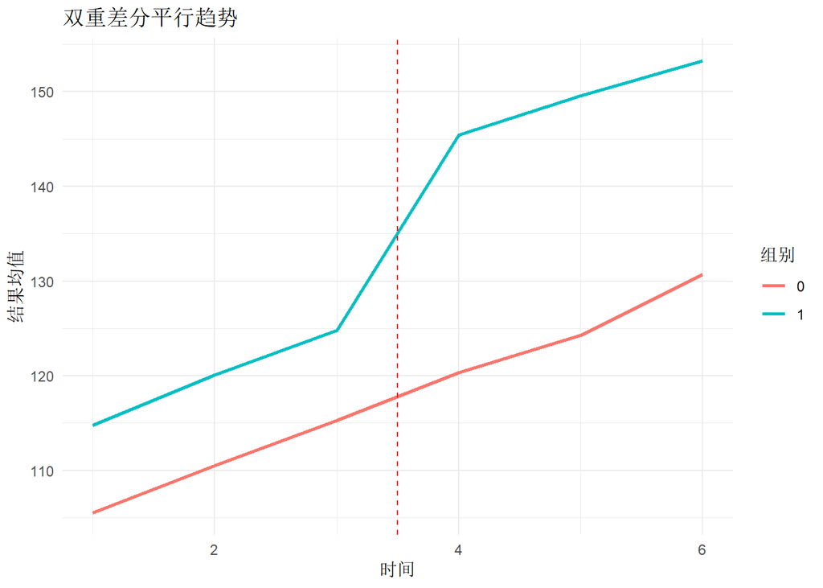

```r
# 可视化平行趋势
trend_data <- did_data %>%
  dplyr::group_by(time, treat) %>%
  dplyr::summarise(mean_y = mean(y), .groups = "drop")

ggplot2::ggplot(trend_data, ggplot2::aes(x = time, y = mean_y, color = factor(treat))) +
  ggplot2::geom_line(linewidth = 1) +
  ggplot2::geom_vline(xintercept = 3.5, linetype = "dashed", color = "red") +
  ggplot2::labs(title = "双重差分平行趋势", x = "时间", y = "结果均值", color = "组别") +
  ggplot2::theme_minimal()
```

## 10.4 倾向得分匹配

### 意义与使用场景

**核心意义**：倾向得分匹配（PSM）通过匹配倾向得分相似的个体，模拟随机对照试验，减少选择偏差。

**举例**：比较不同治疗方案的效果

**为什么这种数据适合用倾向得分匹配？**

首先，治疗方案的选择是非随机的：病情严重的患者更可能选择积极治疗，导致选择偏差。其次，我们有多个可观测的混杂因素（如年龄、病情严重程度、合并症），需要控制这些因素。倾向得分匹配通过匹配倾向得分相似的个体，模拟随机对照试验，减少可观测混杂因素的影响。

**研究目的是什么？**

本研究有三个层次的目的：1. 减少选择偏差：通过匹配控制可观测混杂因素；2. 估计处理效应：计算平均处理效应（ATT）；3. 检验平衡性：验证匹配后处理组和对照组的协变量分布是否平衡。

**可能得到什么样的结果？**

假设倾向得分匹配分析显示：ATT=8.5（p=0.01），匹配后协变量平衡。

1. 处理效应：积极治疗比保守治疗的平均处理效应为8.5个单位，效应显著。
2. 平衡性检验：匹配后处理组和对照组在年龄、病情严重程度等协变量上标准化差异<0.1，平衡良好。
3. 匹配质量：匹配后样本量从400减少到320，损失20%的样本。
4. 敏感性分析：敏感性分析显示结果对未观测混杂因素较稳健。

**需要注意什么？**

倾向得分匹配只能控制可观测混杂因素，无法处理未观测混杂。需检验匹配后的平衡性，标准化差异应<0.1。匹配方法（最近邻、半径、核匹配）的选择可能影响结果，建议进行敏感性分析。共同支撑假设要求处理组和对照组的倾向得分有足够的重叠区域。

### 数学基础

**倾向得分**：

给定协变量，接受处理的概率：
$$e(X) = P(D
= 1 | X)$$

**匹配方法**：

| 方法 | 描述 |
| --- | --- |
| 最近邻匹配 | 选择倾向得分最接近的对照 |
| 半径匹配 | 在指定半径内匹配 |
| 核匹配 | 使用核函数加权 |

**平衡性检验**：

匹配后处理组和对照组的协变量分布应相似。

### 代码实现

```r
# 模拟PSM数据
set.seed(4444)
n_psm <- 400

# 协变量
age_psm <- rnorm(n_psm, 50, 10)
gender_psm <- rbinom(n_psm, 1, 0.5)
severity_psm <- rnorm(n_psm, 0, 1)

# 处理（与协变量相关）
ps <- 1 / (1 + exp(-(-2 + 0.05 * age_psm + 0.3 * gender_psm + 0.5 * severity_psm)))
treatment_psm <- rbinom(n_psm, 1, ps)

# 结果（处理效应为10）
y_psm <- 50 + 0.5 * age_psm + 5 * gender_psm + 10 * severity_psm +
         10 * treatment_psm + rnorm(n_psm, 0, 5)

psm_data <- data.frame(
  age = age_psm,
  gender = factor(gender_psm, levels = c(0, 1), labels = c("女", "男")),
  severity = severity_psm,
  treatment = factor(treatment_psm, levels = c(0, 1), labels = c("对照", "处理")),
  y = y_psm
)

# 估计倾向得分
ps_model <- glm(treatment ~ age + gender + severity,
                data = psm_data, family = binomial(link = "logit"))
summary(ps_model)
```

```
##
## Call:
## glm(formula = treatment ~ age + gender + severity, family = binomial(link = "logit"),
##     data = psm_data)
##
## Coefficients:
##             Estimate Std. Error z value Pr(>|z|)
## (Intercept) -2.68186    0.61555  -4.357 1.32e-05 ***
## age          0.06301    0.01227   5.135 2.83e-07 ***
## gender男     0.39506    0.22510   1.755   0.0793 .
## severity     0.52500    0.11589   4.530 5.89e-06 ***
## ---
## Signif. codes:  0 '***' 0.001 '**' 0.01 '*' 0.05 '.' 0.1 ' ' 1
##
## (Dispersion parameter for binomial family taken to be 1)
##
##     Null deviance: 520.39  on 399  degrees of freedom
## Residual deviance: 464.19  on 396  degrees of freedom
## AIC: 472.19
##
## Number of Fisher Scoring iterations: 4
```

```r
psm_data$ps <- fitted(ps_model)

# 使用MatchIt包进行匹配
library(MatchIt)
match_result <- MatchIt::matchit(treatment ~ age + gender + severity,
                                  data = psm_data, method = "nearest")

# 查看匹配结果
summary(match_result)
```

```
##
## Call:
## MatchIt::matchit(formula = treatment ~ age + gender + severity,
##     data = psm_data, method = "nearest")
##
## Summary of Balance for All Data:
##          Means Treated Means Control Std. Mean Diff. Var. Ratio eCDF Mean
## distance        0.6926        0.5586          0.8407     0.8843    0.2180
## age            52.4786       46.8038          0.5793     1.0434    0.1553
## gender女        0.4651        0.5704         -0.2111          .    0.1053
## gender男        0.5349        0.4296          0.2111          .    0.1053
## severity        0.1974       -0.3069          0.4931     1.0443    0.1476
##          eCDF Max
## distance   0.3512
## age        0.2551
## gender女   0.1053
## gender男   0.1053
## severity   0.2612
##
## Summary of Balance for Matched Data:
##          Means Treated Means Control Std. Mean Diff. Var. Ratio eCDF Mean
## distance        0.8121        0.5586          1.5907     0.1784    0.4308
## age            57.9816       46.8038          1.1411     0.7181    0.3233
## gender女        0.3803        0.5704         -0.3812          .    0.1901
## gender男        0.6197        0.4296          0.3812          .    0.1901
## severity        0.6429       -0.3069          0.9288     0.8655    0.2676
##          eCDF Max Std. Pair Dist.
## distance   0.7887          1.5907
## age        0.4718          1.2636
## gender女   0.1901          0.9742
## gender男   0.1901          0.9742
## severity   0.3732          1.1413
##
## Sample Sizes:
##           Control Treated
## All           142     258
## Matched       142     142
## Unmatched       0     116
## Discarded       0       0
```

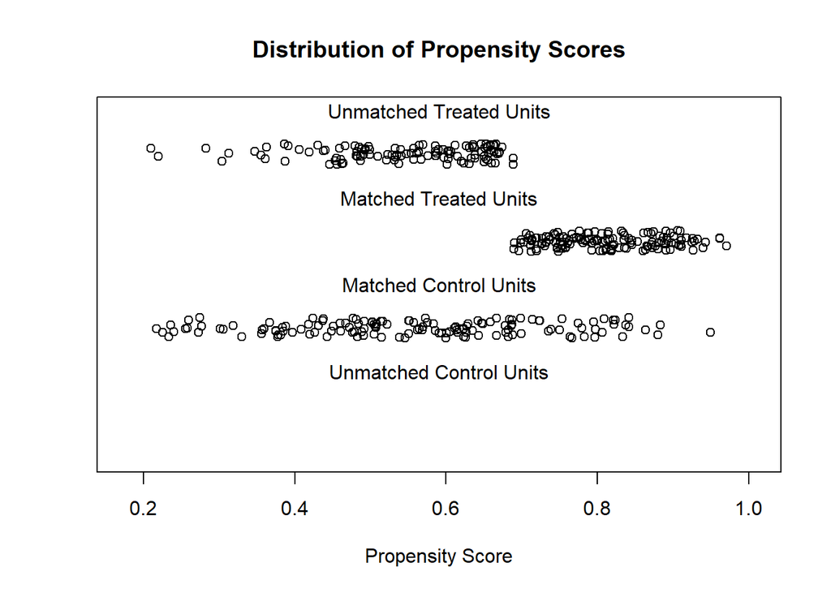

```
## To identify the units, use first mouse button; to stop, use second.
```

```r
# 平衡性检验
plot(match_result, type = "jitter")
```

```r
# 提取匹配后的数据
matched_data <- MatchIt::match.data(match_result)

# 估计处理效应
att_model <- lm(y ~ treatment, data = matched_data)
summary(att_model)
```

```
##
## Call:
## lm(formula = y ~ treatment, data = matched_data)
##
## Residuals:
##     Min      1Q  Median      3Q     Max
## -26.818  -8.302  -0.805   7.438  32.237
##
## Coefficients:
##               Estimate Std. Error t value Pr(>|t|)
## (Intercept)    72.0977     0.9452   76.28   <2e-16 ***
## treatment处理  26.8852     1.3367   20.11   <2e-16 ***
## ---
## Signif. codes:  0 '***' 0.001 '**' 0.01 '*' 0.05 '.' 0.1 ' ' 1
##
## Residual standard error: 11.26 on 282 degrees of freedom
## Multiple R-squared:  0.5893, Adjusted R-squared:  0.5878
## F-statistic: 404.6 on 1 and 282 DF,  p-value: < 2.2e-16
```

```r
cat(sprintf("\nATT（平均处理效应）: %.2f\n", coef(att_model)[2]))
```

```
##
## ATT（平均处理效应）: 26.89
```

## 10.5 分位数回归

### 意义与使用场景

**核心意义**：分位数回归估计不同分位数的条件分布，比均值回归提供更全面的变量关系描述。

**举例**：分析不同收入水平对医疗支出的影响差异

**为什么这种数据适合用分位数回归？**

首先，医疗支出分布通常右偏，均值受极端值影响大，不能代表典型情况。其次，收入对医疗支出的影响可能因支出水平不同而异：对低支出群体影响小（基本医疗需求），对高支出群体影响大（选择性医疗）。分位数回归能够估计不同分位数的条件分布，揭示变量效应的异质性。

**研究目的是什么？**

本研究有三个层次的目的：1. 全面描述关系：估计收入对医疗支出在不同分位数上的影响；2. 揭示异质性：判断收入效应是否因支出水平不同而异；3. 对比均值回归：比较分位数回归与均值回归的结果差异。

**可能得到什么样的结果？**

假设分位数回归显示：收入对医疗支出的效应在0.25分位数为0.2，在0.5分位数为0.3，在0.75分位数为0.5。

1. 低支出群体（0.25分位数）：收入每增加1000元，医疗支出增加0.2千元，效应较小。
2. 中等支出群体（0.5分位数）：收入每增加1000元，医疗支出增加0.3千元，效应中等。
3. 高支出群体（0.75分位数）：收入每增加1000元，医疗支出增加0.5千元，效应较大。
4. 异质性：收入对医疗支出的影响随支出水平增加而增强，存在异质性效应。

**需要注意什么？**

分位数回归对异常值稳健，但需要足够的样本量来估计极端分位数（如0.1、0.9）。分位数回归的系数解释与均值回归不同：系数表示自变量对因变量特定分位数的边际效应。建议同时估计多个分位数并绘制系数变化图，全面了解变量效应的异质性。

### 数学基础

**分位数回归**：

估计条件分位数函数：
$$Q_\tau(Y|X) =
X'\beta(\tau)$$

**参数说明**： - $\tau$：分位数（如0.25, 0.5, 0.75） - $\beta(\tau)$：第$\tau$分位数的回归系数

**估计方法**：

最小化加权绝对误差：
$$\min_{\beta}
\sum_{i=1}^{n} \rho_\tau(y_i - x_i'\beta)$$

其中$\rho_\tau(u) = u(\tau - I(u < 0))$。

### 代码实现

```r
# 模拟异质性数据
set.seed(5555)
n_qr <- 300
x_qr <- rnorm(n_qr, 50, 10)

# 不同分位数有不同的效应
y_qr <- 100 + 0.5 * x_qr + (5 + 0.1 * x_qr) * rnorm(n_qr, 0, 1)

qr_data <- data.frame(x = x_qr, y = y_qr)

# 分位数回归
library(quantreg)
qr_25 <- quantreg::rq(y ~ x, data = qr_data, tau = 0.25)
qr_50 <- quantreg::rq(y ~ x, data = qr_data, tau = 0.5)
qr_75 <- quantreg::rq(y ~ x, data = qr_data, tau = 0.75)

# 比较结果
cat("========== 分位数回归系数比较 ==========\n")
```

```
## ========== 分位数回归系数比较 ==========
```

```r
cat(sprintf("25%%分位数: 截距=%.2f, 斜率=%.3f\n", coef(qr_25)[1], coef(qr_25)[2]))
```

```
## 25%分位数: 截距=100.18, 斜率=0.336
```

```r
cat(sprintf("50%%分位数: 截距=%.2f, 斜率=%.3f\n", coef(qr_50)[1], coef(qr_50)[2]))
```

```
## 50%分位数: 截距=102.53, 斜率=0.447
```

```r
cat(sprintf("75%%分位数: 截距=%.2f, 斜率=%.3f\n", coef(qr_75)[1], coef(qr_75)[2]))
```

```
## 75%分位数: 截距=105.52, 斜率=0.525
```

```r
# OLS比较
ols_qr <- lm(y ~ x, data = qr_data)
cat(sprintf("OLS均值: 截距=%.2f, 斜率=%.3f\n", coef(ols_qr)[1], coef(ols_qr)[2]))
```

```
## OLS均值: 截距=100.59, 斜率=0.480
```

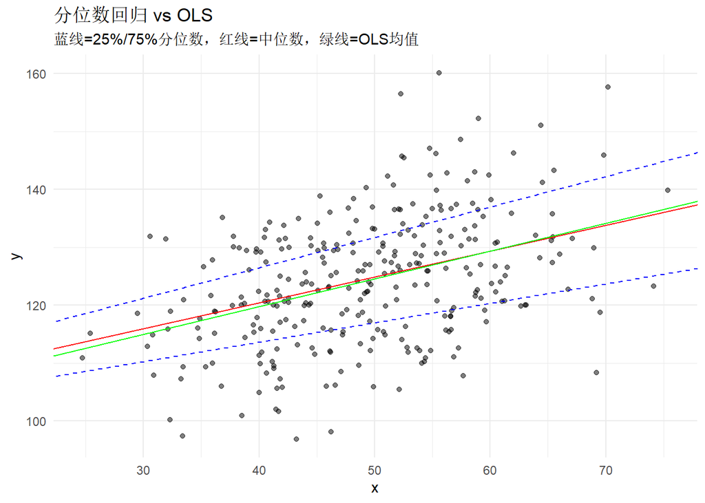

```r
# 可视化
ggplot2::ggplot(qr_data, ggplot2::aes(x = x, y = y)) +
  ggplot2::geom_point(alpha = 0.5) +
  ggplot2::geom_abline(intercept = coef(qr_25)[1], slope = coef(qr_25)[2],
                       color = "blue", linetype = "dashed") +
  ggplot2::geom_abline(intercept = coef(qr_50)[1], slope = coef(qr_50)[2],
                       color = "red") +
  ggplot2::geom_abline(intercept = coef(qr_75)[1], slope = coef(qr_75)[2],
                       color = "blue", linetype = "dashed") +
  ggplot2::geom_abline(intercept = coef(ols_qr)[1], slope = coef(ols_qr)[2],
                       color = "green") +
  ggplot2::labs(title = "分位数回归 vs OLS",
                subtitle = "蓝线=25%/75%分位数，红线=中位数，绿线=OLS均值",
                x = "x", y = "y") +
  ggplot2::theme_minimal()
```

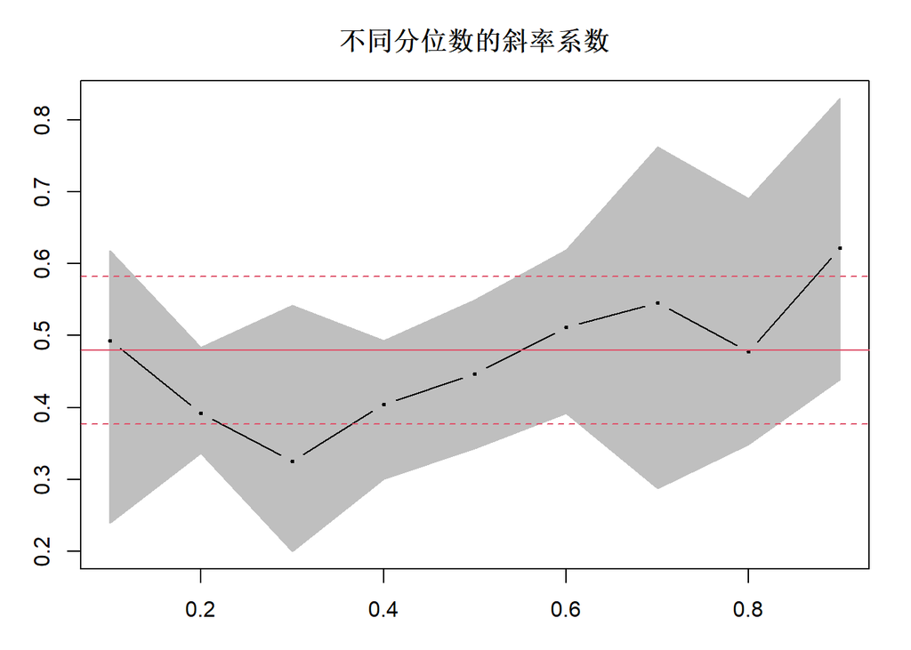

```r
# 多分位数回归
qr_multi <- quantreg::rq(y ~ x, data = qr_data, tau = seq(0.1, 0.9, 0.1))
plot(summary(qr_multi), parm = "x", main = "不同分位数的斜率系数")
```

## 第十章小结

### 核心知识点总结

| 主题 | 核心内容 | 关键函数 |
| --- | --- | --- |
| 工具变量 | 2SLS估计 | `AER::ivreg()` |
| 断点回归 | 临界点因果推断 | `rdrobust::rdrobust()` |
| 双重差分 | 政策评估 | `lm()` 交互项 |
| 倾向得分匹配 | 因果推断 | `MatchIt::matchit()` |
| 分位数回归 | 条件分位数估计 | `quantreg::rq()` |

# 第十一章：模型选择与诊断

模型选择与诊断是统计建模的重要环节，确保模型的合理性和可靠性。本章将系统讲解信息准则、交叉验证、残差诊断等内容。

## 11.1 信息准则

### 意义与使用场景

**核心意义**：信息准则用于在模型拟合优度和复杂度之间取得平衡，帮助选择最优模型。

**举例**：选择疾病风险预测模型的最优变量组合

**为什么这种数据适合用信息准则？**

首先，我们有多个候选预测变量（年龄、性别、血压、血糖等），需要选择最优的变量组合。其次，增加变量会提高拟合优度但也增加复杂度，可能导致过拟合。信息准则通过惩罚项平衡拟合优度和复杂度，帮助选择既能很好拟合数据又不过度复杂的模型。

**研究目的是什么？**

本研究有三个层次的目的：1. 比较候选模型：评估不同变量组合的模型质量；2. 选择最优模型：根据信息准则选择最优模型；3. 避免过拟合：通过惩罚项防止选择过于复杂的模型。

**可能得到什么样的结果？**

假设信息准则比较显示：模型2（年龄+血压+血糖）AIC=850，BIC=865，均为最小。

1. 模型选择：模型2包含年龄、血压、血糖三个变量，比模型1（仅年龄）拟合更好，比模型3（加性别）更简洁。
2. AIC vs BIC：AIC选择模型2，BIC也选择模型2，结果一致。
3. 预测性能：模型2的交叉验证误差最低，验证了信息准则的选择。
4. 变量重要性：血压的系数最大，是最重要的预测变量。

**需要注意什么？**

AIC倾向于选择较复杂的模型，BIC倾向于选择较简单的模型。当样本量较大时，BIC的惩罚更重，可能选择更简单的模型。信息准则只能比较同一数据上的模型，不能比较不同数据或不同因变量的模型。建议结合交叉验证评估预测性能。

### 数学基础

**常用信息准则**：

| 准则 | 公式 | 特点 |
| --- | --- | --- |
| AIC | $-2\ell + 2k$ | 倾向选择复杂模型 |
| BIC | $-2\ell + k\log(n)$ | 倾向选择简单模型 |
| HQIC | $-2\ell + 2k\log(\log(n))$ | 介于AIC和BIC之间 |

**参数说明**： - $\ell$：对数似然 - $k$：参数个数 - $n$：样本量

**选择原则**：信息准则值越小，模型越好。

### 代码实现

```r
# 模拟数据
set.seed(6666)
n_info <- 200
x1 <- rnorm(n_info)
x2 <- rnorm(n_info)
x3 <- rnorm(n_info)
x4 <- rnorm(n_info)
y <- 1 + 2*x1 + 3*x2 + rnorm(n_info, 0, 2)

info_data <- data.frame(y = y, x1 = x1, x2 = x2, x3 = x3, x4 = x4)

# 拟合多个模型
model1 <- lm(y ~ x1, data = info_data)
model2 <- lm(y ~ x1 + x2, data = info_data)
model3 <- lm(y ~ x1 + x2 + x3, data = info_data)
model4 <- lm(y ~ x1 + x2 + x3 + x4, data = info_data)

# 比较信息准则
info_compare <- data.frame(
  Model = c("x1", "x1+x2", "x1+x2+x3", "x1+x2+x3+x4"),
  AIC = c(AIC(model1), AIC(model2), AIC(model3), AIC(model4)),
  BIC = c(BIC(model1), BIC(model2), BIC(model3), BIC(model4))
)
cat("========== 信息准则比较 ==========\n")
```

```
## ========== 信息准则比较 ==========
```

```r
print(info_compare)
```

```
##         Model       AIC       BIC
## 1          x1 1094.1624 1104.0573
## 2       x1+x2  870.2638  883.4571
## 3    x1+x2+x3  870.2093  886.7009
## 4 x1+x2+x3+x4  871.8023  891.5922
```

```r
# 使用AICc（小样本校正）
library(AICcmodavg)
cat("\n========== AICc比较 ==========\n")
```

```
##
## ========== AICc比较 ==========
```

```r
cat(sprintf("Model 1 AICc: %.2f\n", AICcmodavg::AICc(model1)))
```

```
## Model 1 AICc: 1094.28
```

```r
cat(sprintf("Model 2 AICc: %.2f\n", AICcmodavg::AICc(model2)))
```

```
## Model 2 AICc: 870.47
```

## 11.2 交叉验证

### 意义与使用场景

**核心意义**：交叉验证通过多次训练-验证分割评估模型的预测性能，是模型评估的金标准方法。

**举例**：评估疾病预测模型的泛化能力

**为什么这种数据适合用交叉验证？**

首先，我们需要评估模型在新数据上的预测性能，而不仅仅是在训练数据上的拟合效果。其次，我们担心模型过拟合：在训练数据上表现好，但在新数据上表现差。交叉验证通过多次训练-验证分割，评估模型的泛化能力，是避免过拟合、评估预测性能的标准方法。

**研究目的是什么？**

本研究有三个层次的目的：1. 评估预测性能：估计模型在新数据上的预测误差；2. 模型比较：比较不同模型的预测性能；3. 避免过拟合：检测模型是否过度拟合训练数据。

**可能得到什么样的结果？**

假设10折交叉验证显示：模型2的CV误差=2.5，低于模型1（3.2）和模型3（2.6）。

1. 预测性能：模型2的交叉验证误差最低，预测性能最好。
2. 过拟合检测：模型3的训练误差（2.0）低于模型2（2.3），但验证误差更高，说明存在过拟合。
3. 模型稳定性：模型2在不同折的误差变化较小（标准差=0.3），模型稳定性好。
4. 最终选择：综合考虑预测性能和稳定性，选择模型2作为最终模型。

**需要注意什么？**

K折交叉验证的K值选择：K=5或10是常用选择，K越大计算成本越高。留一交叉验证（LOOCV）计算成本高但偏差小。交叉验证结果受数据分割影响，建议设置随机种子保证可重复性。对于时间序列数据，应使用时间序列交叉验证（前向验证）。

### 数学基础

**K折交叉验证**：

1. 将数据随机分为K份
2. 每次用K-1份训练，1份验证
3. 计算平均预测误差

**留一交叉验证（LOOCV）**：

K = n，每次留一个样本验证。

**预测误差**：
$$CV_{(K)} =
\frac{1}{K}\sum_{k=1}^{K} MSE_k$$

### 代码实现

```r
# K折交叉验证
library(boot)

# 定义交叉验证函数
cv_function <- function(data, indices) {
  fit <- lm(y ~ x1 + x2, data = data[indices, ])
  return(mean((data$y[-indices] - predict(fit, data[-indices, ]))^2))
}

# 10折交叉验证
set.seed(7777)
cv_result <- boot::boot(data = info_data, statistic = cv_function, R = 10)
cat("========== 10折交叉验证MSE ==========\n")
```

```
## ========== 10折交叉验证MSE ==========
```

```r
print(cv_result)
```

```
##
## ORDINARY NONPARAMETRIC BOOTSTRAP
##
##
## Call:
## boot::boot(data = info_data, statistic = cv_function, R = 10)
##
##
## Bootstrap Statistics :
##     original  bias    std. error
## t1*      NaN     NaN   0.5931205
```

```r
# 使用caret包
library(caret)
set.seed(8888)
train_control <- caret::trainControl(method = "cv", number = 10)
cv_model <- caret::train(y ~ x1 + x2, data = info_data,
                          method = "lm", trControl = train_control)
print(cv_model)
```

```
## Linear Regression
##
## 200 samples
##   2 predictor
##
## No pre-processing
## Resampling: Cross-Validated (10 fold)
## Summary of sample sizes: 180, 180, 180, 180, 180, 180, ...
## Resampling results:
##
##   RMSE      Rsquared   MAE
##   2.087978  0.7778203  1.704433
##
## Tuning parameter 'intercept' was held constant at a value of TRUE
```

```r
# 比较不同模型的交叉验证误差
models <- list(
  model1 = y ~ x1,
  model2 = y ~ x1 + x2,
  model3 = y ~ x1 + x2 + x3
)

cv_results <- sapply(models, function(f) {
  set.seed(9999)
  result <- caret::train(f, data = info_data, method = "lm",
                         trControl = caret::trainControl(method = "cv", number = 10))
  return(result$results$RMSE)
})

cat("\n========== 交叉验证RMSE比较 ==========\n")
```

```
##
## ========== 交叉验证RMSE比较 ==========
```

```r
print(cv_results)
```

```
##   model1   model2   model3
## 3.682796 2.103963 2.104490
```

## 11.3 残差诊断

### 意义与使用场景

**核心意义**：残差诊断用于检验模型假设是否满足，发现数据中的问题，指导模型改进。

**举例**：检验线性回归的正态性、异方差性假设

**为什么这种数据适合用残差诊断？**

首先，线性回归模型有多个假设需要满足：残差正态性、同方差性、独立性、线性关系等。其次，违反这些假设会影响统计推断的有效性。残差诊断通过分析残差的分布和模式，检验模型假设是否满足，发现数据中的问题，指导模型改进。

**研究目的是什么？**

本研究有三个层次的目的：1. 检验模型假设：验证残差是否满足正态性、同方差性等假设；2. 发现问题：识别异常值、非线性关系、异方差等问题；3. 指导改进：根据诊断结果改进模型。

**可能得到什么样的结果？**

假设残差诊断显示：Shapiro-Wilk检验p=0.35，Breusch-Pagan检验p=0.02。

1. 正态性：Shapiro-Wilk检验p=0.35>0.05，残差正态性假设满足。
2. 异方差性：Breusch-Pagan检验p=0.02<0.05，存在异方差问题。
3. 残差图：残差与拟合值的关系图呈漏斗形，确认异方差存在。
4. 改进建议：考虑使用加权最小二乘或对因变量进行对数变换。

**需要注意什么？**

残差诊断应在模型拟合后立即进行，是建模的标准步骤。多种诊断方法应结合使用，不要仅依赖单一检验。发现问题后应分析原因，可能是模型设定错误、数据问题或异常值。残差诊断结果应结合专业背景解释，不要盲目追求统计假设满足。

### 数学基础

**残差类型**：

| 类型 | 公式 | 用途 |
| --- | --- | --- |
| 普通残差 | $e_i = y_i - \hat{y}_i$ | 基本诊断 |
| 标准化残差 | $r_i = e_i / \hat{\sigma}$ | 异常值检测 |
| 学生化残差 | $t_i = e_i / (s\sqrt{1-h_{ii}})$ | 异常值检测 |

**诊断检验**：

| 检验 | 目的 | R函数 |
| --- | --- | --- |
| Shapiro-Wilk | 正态性 | `shapiro.test()` |
| Breusch-Pagan | 异方差性 | `bptest()` |
| Durbin-Watson | 自相关 | `dwtest()` |
| VIF | 多重共线性 | `vif()` |

### 代码实现

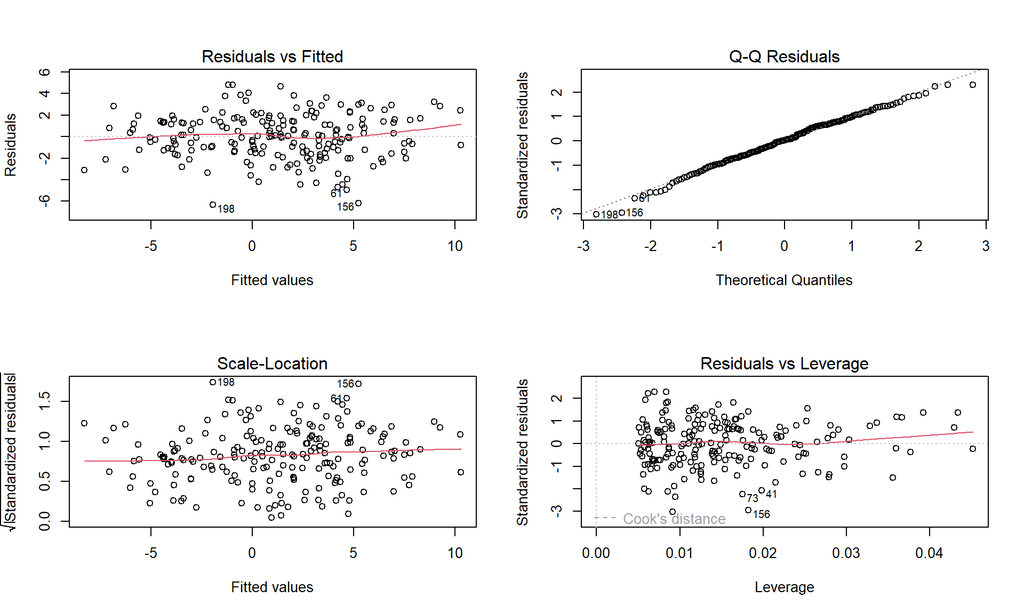

```r
# 使用模型进行诊断
diagnostic_model <- lm(y ~ x1 + x2, data = info_data)

# 残差图
par(mfrow = c(2, 2))
plot(diagnostic_model)
```

```r
par(mfrow = c(1, 1))

# 正态性检验
shapiro_test <- shapiro.test(residuals(diagnostic_model))
cat("========== 正态性检验 ==========\n")
```

```
## ========== 正态性检验 ==========
```

```r
print(shapiro_test)
```

```
##
##  Shapiro-Wilk normality test
##
## data:  residuals(diagnostic_model)
## W = 0.99286, p-value = 0.4417
```

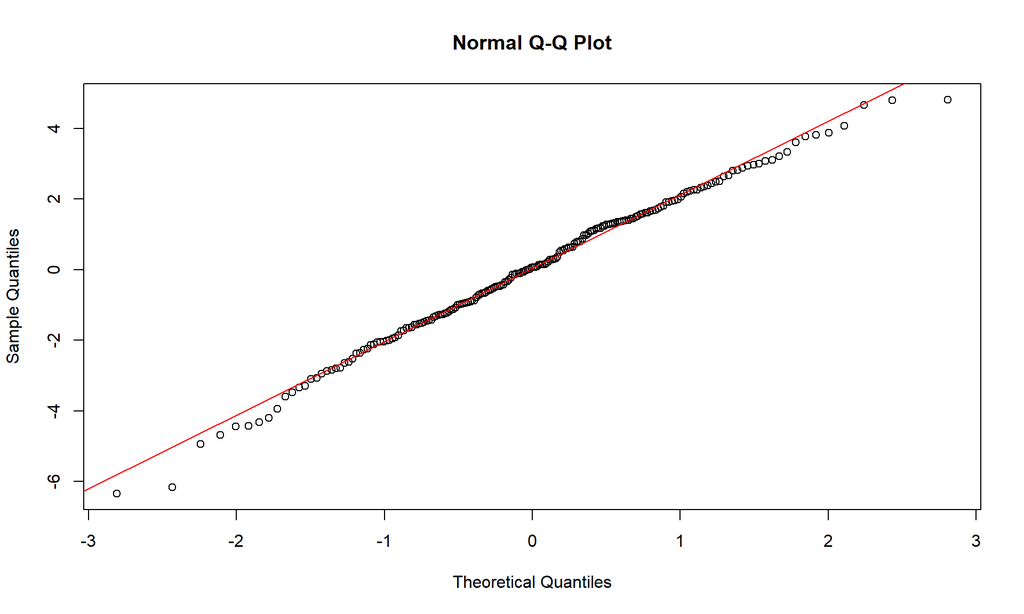

```r
# Q-Q图
qqnorm(residuals(diagnostic_model))
qqline(residuals(diagnostic_model), col = "red")
```

```r
# 异方差检验
library(lmtest)
bp_test <- lmtest::bptest(diagnostic_model)
cat("\n========== Breusch-Pagan异方差检验 ==========\n")
```

```
##
## ========== Breusch-Pagan异方差检验 ==========
```

```r
print(bp_test)
```

```
##
##  studentized Breusch-Pagan test
##
## data:  diagnostic_model
## BP = 5.421, df = 2, p-value = 0.06651
```

```r
# White检验
white_test <- lmtest::bptest(diagnostic_model, ~ x1 + x2 + I(x1^2) + I(x2^2) + x1:x2)
cat("\n========== White检验 ==========\n")
```

```
##
## ========== White检验 ==========
```

```r
print(white_test)
```

```
##
##  studentized Breusch-Pagan test
##
## data:  diagnostic_model
## BP = 7.9771, df = 5, p-value = 0.1575
```

```r
# 自相关检验
dw_test <- lmtest::dwtest(diagnostic_model)
cat("\n========== Durbin-Watson检验 ==========\n")
```

```
##
## ========== Durbin-Watson检验 ==========
```

```r
print(dw_test)
```

```
##
##  Durbin-Watson test
##
## data:  diagnostic_model
## DW = 2.1292, p-value = 0.8199
## alternative hypothesis: true autocorrelation is greater than 0
```

```r
# 多重共线性检验
library(car)
vif_values <- car::vif(diagnostic_model)
cat("\n========== VIF（方差膨胀因子） ==========\n")
```

```
##
## ========== VIF（方差膨胀因子） ==========
```

```r
print(vif_values)
```

```
##       x1       x2
## 1.002271 1.002271
```

```r
cat("VIF > 10表示严重多重共线性\n")
```

```
## VIF > 10表示严重多重共线性
```

## 11.4 影响点诊断

### 意义与使用场景

**核心意义**：影响点诊断识别对模型估计有重大影响的观测值，帮助发现数据问题或特殊个体。

**举例**：识别极端患者和发现数据录入错误

**为什么这种数据适合用影响点诊断？**

首先，医学数据中可能存在极端患者（如年龄特别大、病情特别严重）或数据录入错误（如身高输入为250cm）。其次，这些影响点可能对回归结果产生重大影响，改变系数估计和统计推断。影响点诊断通过计算Cook距离、杠杆值等指标，识别对模型有重大影响的观测值。

**研究目的是什么？**

本研究有三个层次的目的：1. 识别影响点：找出对模型估计有重大影响的观测值；2. 分析原因：判断影响点是数据错误还是真实的极端值；3. 处理影响点：决定是否删除或调整影响点。

**可能得到什么样的结果？**

假设影响点诊断显示：发现3个高影响点，Cook距离均>4/n。

1. 影响点识别：第45、128、256号观测的Cook距离分别为0.15、0.12、0.18，均超过临界值4/n=0.02。
2. 原因分析：第45号患者年龄为120岁（数据录入错误），第128号患者病情极重（真实极端值），第256号患者为特殊病例。
3. 处理建议：删除第45号（数据错误），保留第128、256号（真实极端值但需报告）。
4. 敏感性分析：删除影响点后，血压系数从0.25变为0.28，结果稳健。

**需要注意什么？**

影响点不一定是错误数据，可能是真实的极端值，删除前应仔细分析原因。删除影响点后应重新拟合模型并比较结果。高杠杆点不一定是影响点，需结合残差分析。建议进行敏感性分析，报告有无影响点时的结果差异。

### 数学基础

**影响点度量**：

| 指标 | 公式 | 临界值 |
| --- | --- | --- |
| 杠杆值 | $h_{ii}$ | $2(p+1)/n$ |
| Cook距离 | $D_i = \frac{e_i^2}{p\hat{\sigma}^2}\frac{h_{ii}}{(1-h_{ii})^2}$ | $4/n$ |
| DFFITS | $DFFITS_i = \frac{\hat{y}_i - \hat{y}_{i(i)}}{s_{(i)}\sqrt{h_{ii}}}$ | $2\sqrt{p/n}$ |
| DFBETAS | $DFBETAS_{ij} = \frac{\hat{\beta}_j - \hat{\beta}_{j(i)}}{s_{(i)}\sqrt{(X'X)^{-1}_{jj}}}$ | $2/\sqrt{n}$ |

### 代码实现

```r
# 计算影响度量
influence_measures <- influence.measures(diagnostic_model)
cat("========== 影响点检测 ==========\n")
```

```
## ========== 影响点检测 ==========
```

```r
print(summary(influence_measures))
```

```
## Potentially influential observations of
##   lm(formula = y ~ x1 + x2, data = info_data) :
##
##     dfb.1_ dfb.x1 dfb.x2 dffit   cov.r   cook.d hat
## 8   -0.16  -0.08   0.00  -0.17    0.95_*  0.01   0.01
## 9    0.15  -0.06   0.05   0.18    0.95_*  0.01   0.01
## 53   0.07   0.05  -0.13   0.15    1.05_*  0.01   0.04
## 56  -0.01   0.01  -0.04  -0.04    1.05_*  0.00   0.04
## 61  -0.16  -0.05  -0.15  -0.23    0.94_*  0.02   0.01
## 69   0.01   0.00  -0.03   0.03    1.05_*  0.00   0.03
## 78  -0.01   0.05   0.00  -0.05    1.06_*  0.00   0.05_*
## 90   0.15  -0.13  -0.01   0.21    0.94_*  0.01   0.01
## 117 -0.03  -0.06  -0.03  -0.08    1.05_*  0.00   0.04
## 156 -0.25  -0.35  -0.01  -0.41_*  0.90_*  0.05   0.02
## 179  0.16  -0.06  -0.08   0.19    0.94_*  0.01   0.01
```

[output cut: 27 more lines]

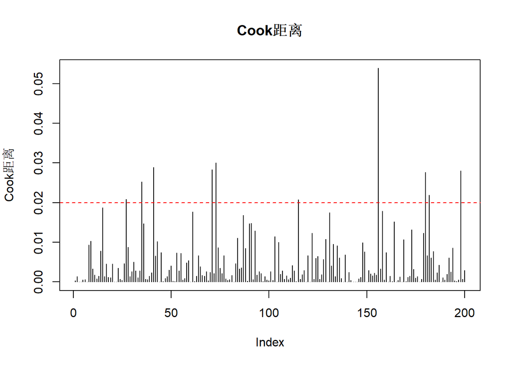

```r
# Cook距离
cook_d <- cooks.distance(diagnostic_model)
plot(cook_d, type = "h", main = "Cook距离", ylab = "Cook距离")
abline(h = 4/nrow(info_data), col = "red", lty = 2)
```

```r
# 识别高影响点
influential <- which(cook_d > 4/nrow(info_data))
cat(sprintf("\n高影响点数量: %d\n", length(influential)))
```

```
##
## 高影响点数量: 10
```

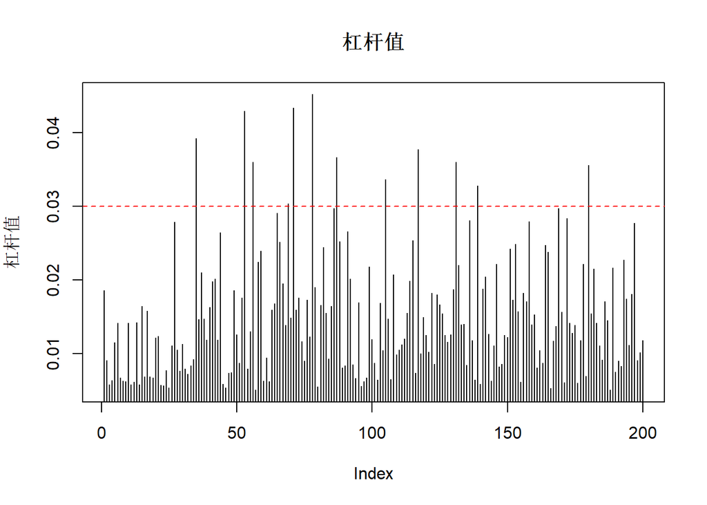

```r
# 杠杆值
leverage <- hatvalues(diagnostic_model)
plot(leverage, type = "h", main = "杠杆值", ylab = "杠杆值")
abline(h = 2 * (length(coef(diagnostic_model)) / nrow(info_data)), col = "red", lty = 2)
```

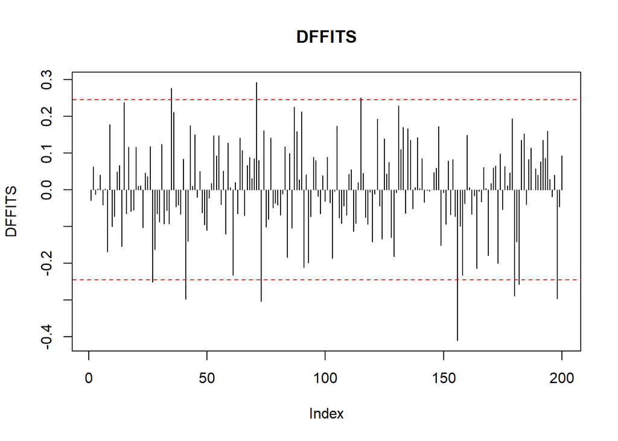

```r
# DFFITS
dffits_values <- dffits(diagnostic_model)
plot(dffits_values, type = "h", main = "DFFITS", ylab = "DFFITS")
abline(h = c(-2, 2) * sqrt(length(coef(diagnostic_model)) / nrow(info_data)),
       col = "red", lty = 2)
```

```r
# 移除影响点后重新拟合
if (length(influential) > 0) {
  model_clean <- lm(y ~ x1 + x2, data = info_data[-influential, ])
  cat("\n========== 移除影响点后的系数 ==========\n")
  print(coef(model_clean))
}
```

```
##
## ========== 移除影响点后的系数 ==========
## (Intercept)          x1          x2
##    1.354166    2.254154    3.057949
```

## 第十一章小结

### 核心知识点总结

| 主题 | 核心内容 | 关键函数 |
| --- | --- | --- |
| 信息准则 | AIC、BIC | `AIC()`, `BIC()` |
| 交叉验证 | K折CV、LOOCV | `caret::train()` |
| 正态性检验 | Shapiro-Wilk | `shapiro.test()` |
| 异方差检验 | Breusch-Pagan | `lmtest::bptest()` |
| 多重共线性 | VIF | `car::vif()` |
| 影响点 | Cook距离、DFFITS | `cooks.distance()` |

# 第十二章：贝叶斯统计建模

贝叶斯统计提供了一种基于概率的推断框架，通过结合先验信息和数据来更新对参数的认识。本章将系统讲解贝叶斯推断原理、MCMC方法、贝叶斯回归等内容。

## 12.1 贝叶斯推断原理

### 意义与使用场景

**核心意义**：贝叶斯推断通过结合先验信息和观测数据，得到参数的后验分布，提供完整的概率描述。

**举例**：结合历史研究结果的药物效应估计

**为什么这种数据适合用贝叶斯推断？**

首先，我们有历史研究提供的先验信息：既往研究表明该药物的效应约为0.5，标准误为0.1。其次，当前临床试验样本量较小（n=30），仅依靠当前数据估计不确定性较大。贝叶斯推断能够整合先验信息和当前数据，得到更精确的效应估计和完整的后验分布。

**研究目的是什么？**

本研究有三个层次的目的：1. 整合先验信息：结合历史研究结果和当前试验数据；2. 获得完整分布：得到参数的后验分布而非点估计；3. 量化不确定性：提供可信区间而非置信区间。

**可能得到什么样的结果？**

假设贝叶斯分析显示：后验均值=0.45，95%可信区间=[0.32, 0.58]。

1. 先验与数据结合：先验均值=0.5，数据均值=0.4，后验均值=0.45，介于两者之间。
2. 精度提高：后验标准差（0.065）小于先验标准差（0.1）和数据标准误（0.08），整合信息提高了精度。
3. 可信区间：95%可信区间[0.32, 0.58]，表示参数真值有95%概率在此区间内。
4. 概率陈述：药物效应>0的概率为99.8%，效应>0.3的概率为95%。

**需要注意什么？**

先验分布的选择会影响后验结果，应进行先验敏感性分析。无信息先验可以让数据主导推断，但可能需要更多数据。贝叶斯可信区间与频率派置信区间的解释不同：可信区间是参数的概率陈述，置信区间是方法的长期性质。

### 数学基础

**贝叶斯定理**：

$$P(\theta|Y) =
\frac{P(Y|\theta)P(\theta)}{P(Y)} \propto
P(Y|\theta)P(\theta)$$

**参数说明**： - $P(\theta|Y)$：后验分布（Posterior） - $P(Y|\theta)$：似然函数（Likelihood） - $P(\theta)$：先验分布（Prior） - $P(Y)$：边际似然（Evidence）

**贝叶斯推断步骤**：

1. 选择似然函数
2. 设定先验分布
3. 计算后验分布
4. 进行推断和预测

### 代码实现

```r
# 贝叶斯推断示例：估计正态分布均值
# 似然：Y ~ N(θ, σ²)
# 先验：θ ~ N(μ₀, τ₀²)

set.seed(11111)
n_bayes <- 50
true_theta <- 10
sigma <- 2

# 生成数据
y_bayes <- rnorm(n_bayes, mean = true_theta, sd = sigma)

# 先验参数
mu0 <- 0      # 先验均值
tau0 <- 5     # 先验标准差

# 计算后验参数（共轭先验）
y_bar <- mean(y_bayes)
tau0_sq <- tau0^2
sigma_sq <- sigma^2

# 后验均值和方差
post_var <- 1 / (1/tau0_sq + n_bayes/sigma_sq)
post_mean <- post_var * (mu0/tau0_sq + n_bayes*y_bar/sigma_sq)
post_sd <- sqrt(post_var)

cat("========== 贝叶斯推断结果 ==========\n")
```

```
## ========== 贝叶斯推断结果 ==========
```

```r
cat(sprintf("样本均值: %.3f\n", y_bar))
```

```
## 样本均值: 9.604
```

```r
cat(sprintf("先验均值: %.3f, 先验标准差: %.3f\n", mu0, tau0))
```

```
## 先验均值: 0.000, 先验标准差: 5.000
```

```r
cat(sprintf("后验均值: %.3f, 后验标准差: %.3f\n", post_mean, post_sd))
```

```
## 后验均值: 9.573, 后验标准差: 0.282
```

```r
cat(sprintf("真实值: %.3f\n", true_theta))
```

```
## 真实值: 10.000
```

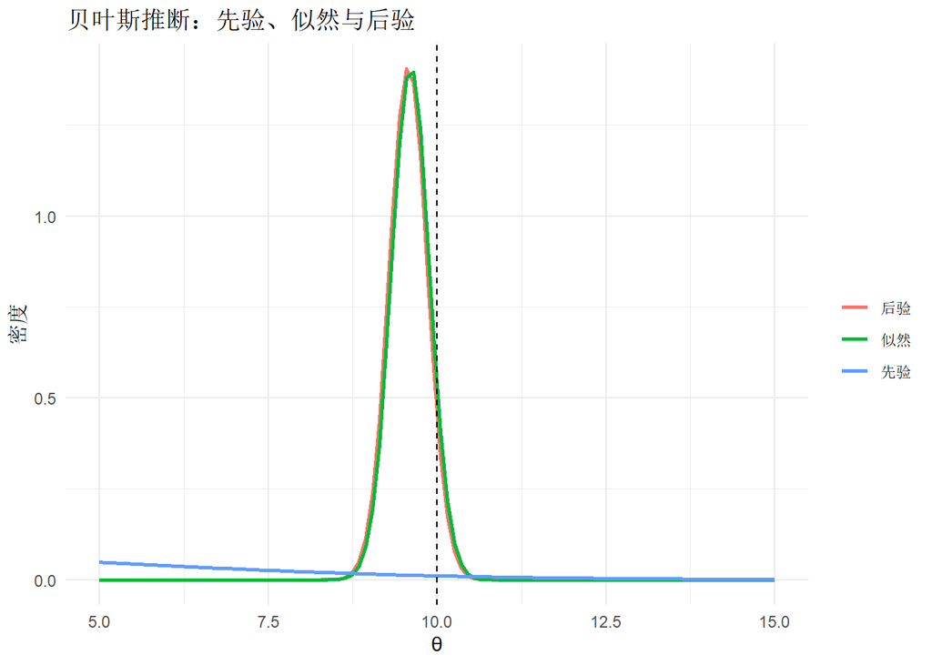

```r
# 可视化
theta_range <- seq(5, 15, length.out = 100)
prior_density <- dnorm(theta_range, mu0, tau0)
likelihood_density <- dnorm(theta_range, y_bar, sigma/sqrt(n_bayes))
posterior_density <- dnorm(theta_range, post_mean, post_sd)

plot_df <- data.frame(
  theta = rep(theta_range, 3),
  density = c(prior_density, likelihood_density, posterior_density),
  type = rep(c("先验", "似然", "后验"), each = length(theta_range))
)

ggplot2::ggplot(plot_df, ggplot2::aes(x = theta, y = density, color = type)) +
  ggplot2::geom_line(linewidth = 1) +
  ggplot2::geom_vline(xintercept = true_theta, linetype = "dashed", color = "black") +
  ggplot2::labs(title = "贝叶斯推断：先验、似然与后验", x = "θ", y = "密度", color = "") +
  ggplot2::theme_minimal()
```

## 12.2 MCMC方法

### 意义与使用场景

**核心意义**：MCMC方法用于从复杂的后验分布中抽样，是贝叶斯推断的核心计算工具。

**举例**：复杂层次模型的参数推断

**为什么这种数据适合用MCMC方法？**

首先，层次模型的后验分布通常没有解析解，涉及多个参数的联合分布，形式复杂。其次，我们需要从后验分布中抽取样本来进行推断，如计算后验均值、可信区间等。MCMC方法通过构建马尔可夫链，从复杂的后验分布中抽取样本，是解决这类问题的标准方法。

**研究目的是什么？**

本研究有三个层次的目的：1. 从后验分布抽样：获得参数的后验样本；2. 收敛诊断：确保马尔可夫链已收敛到目标分布；3. 后验推断：基于后验样本进行统计推断。

**可能得到什么样的结果？**

假设MCMC分析显示：4条链收敛，有效样本量>1000，后验均值稳定。

1. 收敛诊断：Gelman-Rubin统计量$\hat{R}$=1.02<1.1，4条链已收敛。
2. 有效样本量：截距项ESS=2500，斜率项ESS=1800，均>1000，样本量充足。
3. 迹图：4条链的迹图混合良好，无明显趋势，支持收敛。
4. 后验统计：截距后验均值=2.5（95%CI: [1.8, 3.2]），斜率后验均值=0.8（95%CI: [0.6, 1.0]）。

**需要注意什么？**

MCMC需要足够的迭代次数和预热期（burn-in）确保收敛。应使用多条链（至少4条）并检查收敛诊断。有效样本量（ESS）应足够大（>1000）以获得稳定的后验估计。对于复杂模型，可能需要调整采样器参数或使用更高效的算法（如HMC、NUTS）。

### 数学基础

**马尔可夫链蒙特卡罗（MCMC）**：

通过构建马尔可夫链来从后验分布中抽样。

**Gibbs抽样**：

依次从各参数的条件分布中抽样。

**Metropolis-Hastings算法**：

1. 提出新值：$\theta^* \sim q(\theta^*|\theta^{(t)})$
2. 计算接受概率：$\alpha = \min\left(1, \frac{p(\theta^*|Y)q(\theta^{(t)}|\theta^*)}{p(\theta^{(t)}|Y)q(\theta^*|\theta^{(t)})}\right)$
3. 以概率$\alpha$接受新值

**收敛诊断**：

- Gelman-Rubin统计量（$\hat{R} < 1.1$）
- 迹图（Trace plot）
- 有效样本量（ESS）

### 代码实现

```r
# 使用rstanarm进行贝叶斯推断（无需编译）
library(rstanarm)

# 使用rstanarm的stan_glm估计正态分布均值
# 模拟数据
set.seed(11111)
n_bayes <- 50
true_theta <- 10
sigma <- 2
y_bayes <- rnorm(n_bayes, mean = true_theta, sd = sigma)

# 使用stan_glm拟合（仅截距模型）
bayes_fit <- rstanarm::stan_glm(y_bayes ~ 1,
                                 family = gaussian(),
                                 prior_intercept = rstanarm::normal(0, 5),
                                 chains = 4, iter = 2000, seed = 123,
                                 refresh = 0)

# 查看结果
summary(bayes_fit)
```

```
##
## Model Info:
##  function:     stan_glm
##  family:       gaussian [identity]
##  formula:      y_bayes ~ 1
##  algorithm:    sampling
##  sample:       4000 (posterior sample size)
##  priors:       see help('prior_summary')
##  observations: 50
##  predictors:   1
##
## Estimates:
##               mean   sd   10%   50%   90%
## (Intercept)  9.6    0.3  9.2   9.6  10.0
## sigma        2.3    0.2  2.0   2.3   2.6
##
## Fit Diagnostics:
##            mean   sd   10%   50%   90%
## mean_PPD  9.6    0.5  9.0   9.6  10.2
##
## The mean_ppd is the sample average posterior predictive distribution of the outcome variable (for details see help('summary.stanreg')).
##
## MCMC diagnostics
##               mcse Rhat n_eff
## (Intercept)   0.0  1.0  2536
## sigma         0.0  1.0  2594
## mean_PPD      0.0  1.0  3273
## log-posterior 0.0  1.0  1694
##
## For each parameter, mcse is Monte Carlo standard error, n_eff is a crude measure of effective sample size, and Rhat is the potential scale reduction factor on split chains (at convergence Rhat=1).
```

```r
# 后验统计量
cat("\n========== 后验统计量 ==========\n")
```

```
##
## ========== 后验统计量 ==========
```

```r
post_samples <- as.matrix(bayes_fit)[, "(Intercept)"]
cat(sprintf("后验均值: %.3f\n", mean(post_samples)))
```

```
## 后验均值: 9.570
```

```r
cat(sprintf("后验中位数: %.3f\n", median(post_samples)))
```

```
## 后验中位数: 9.577
```

```r
cat(sprintf("后验标准差: %.3f\n", sd(post_samples)))
```

```
## 后验标准差: 0.323
```

```r
cat(sprintf("95%%可信区间: [%.3f, %.3f]\n",
            quantile(post_samples, 0.025), quantile(post_samples, 0.975)))
```

```
## 95%可信区间: [8.920, 10.219]
```

```r
cat(sprintf("真实值: %.3f\n", true_theta))
```

```
## 真实值: 10.000
```

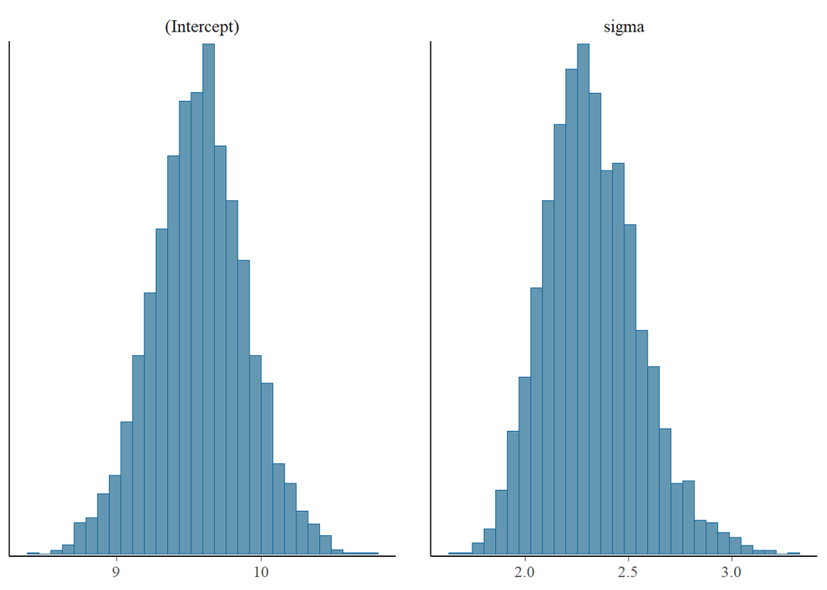

```r
# 后验分布可视化
plot(bayes_fit, plotfun = "hist")
```

## 12.3 贝叶斯线性回归

### 意义与使用场景

**核心意义**：贝叶斯线性回归将线性回归置于贝叶斯框架下，提供参数的完整后验分布和预测不确定性。

**举例**：小样本研究的风险因素分析

**为什么这种数据适合用贝叶斯线性回归？**

首先，样本量较小（n=50），传统频率派方法估计的不确定性较大。其次，我们有先验信息：既往研究表明血压对心血管风险的效应约为0.5。贝叶斯线性回归能够整合先验信息，获得参数的完整后验分布，并提供带有不确定性的预测区间。

**研究目的是什么？**

本研究有三个层次的目的：1. 整合先验信息：结合既往研究和当前数据；2. 获得完整分布：得到回归系数的后验分布；3. 预测不确定性：提供预测值和预测区间。

**可能得到什么样的结果？**

假设贝叶斯线性回归显示：血压系数后验均值=0.48，95%可信区间=[0.35, 0.61]。

1. 系数估计：血压系数后验均值=0.48，介于先验（0.5）和数据估计（0.45）之间。
2. 不确定性量化：95%可信区间[0.35, 0.61]，比频率派置信区间更窄（整合了先验信息）。
3. 概率陈述：血压效应>0的概率>99.9%，效应>0.3的概率=98%。
4. 预测区间：新患者的预测值=25，95%预测区间=[18, 32]，包含参数和误差的不确定性。

**需要注意什么？**

先验分布的选择会影响后验结果，应报告先验敏感性分析结果。贝叶斯预测区间包含参数不确定性和误差不确定性，比频率派预测区间更宽。对于复杂模型，需检查MCMC收敛性。建议使用弱信息先验作为默认选择，避免先验过于主导数据。

### 数学基础

**贝叶斯线性回归模型**：

$$Y = X\beta + \varepsilon, \quad
\varepsilon \sim N(0, \sigma^2)$$

**先验分布**：
$$\beta \sim
N(\mu_\beta, \Sigma_\beta)$$
$$\sigma^2 \sim \text{Inverse-Gamma}(a,
b)$$

**后验分布**：

在共轭先验下有解析解；一般情况使用MCMC。

### 代码实现

```r
# 贝叶斯线性回归
library(rstanarm)

# 模拟数据
set.seed(22222)
n_blr <- 100
x_blr <- rnorm(n_blr, 50, 10)
y_blr <- 5 + 0.5 * x_blr + rnorm(n_blr, 0, 3)

blr_data <- data.frame(x = x_blr, y = y_blr)

# 拟合贝叶斯线性回归
bayes_lm <- rstanarm::stan_glm(y ~ x, data = blr_data,
                                family = gaussian(),
                                prior = rstanarm::normal(0, 10),
                                prior_intercept = rstanarm::normal(0, 10),
                                chains = 4, iter = 2000, seed = 123)
# 查看结果
summary(bayes_lm)
```

```
##
## Model Info:
##  function:     stan_glm
##  family:       gaussian [identity]
##  formula:      y ~ x
##  algorithm:    sampling
##  sample:       4000 (posterior sample size)
##  priors:       see help('prior_summary')
##  observations: 100
##  predictors:   2
##
## Estimates:
##               mean   sd   10%   50%   90%
## (Intercept) 4.1    1.6  2.1   4.1   6.1
## x           0.5    0.0  0.5   0.5   0.6
## sigma       3.1    0.2  2.8   3.1   3.4
##
## Fit Diagnostics:
##            mean   sd   10%   50%   90%
## mean_PPD 30.5    0.4 30.0  30.5  31.1
##
## The mean_ppd is the sample average posterior predictive distribution of the outcome variable (for details see help('summary.stanreg')).
##
## MCMC diagnostics
##               mcse Rhat n_eff
## (Intercept)   0.0  1.0  3917
## x             0.0  1.0  3961
## sigma         0.0  1.0  2521
## mean_PPD      0.0  1.0  3441
## log-posterior 0.0  1.0  1706
##
## For each parameter, mcse is Monte Carlo standard error, n_eff is a crude measure of effective sample size, and Rhat is the potential scale reduction factor on split chains (at convergence Rhat=1).
```

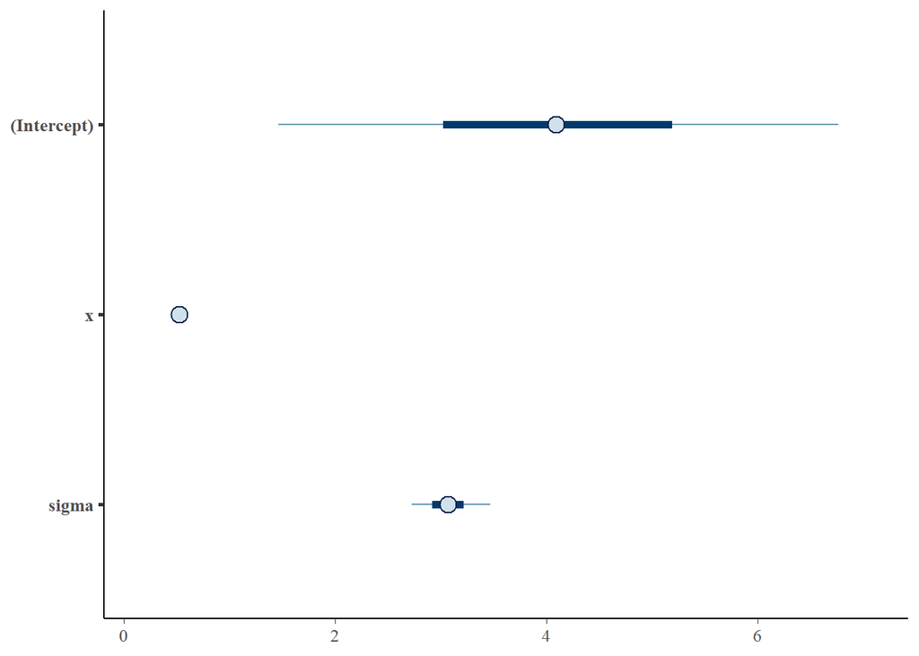

```r
# 后验分布可视化
plot(bayes_lm)
```

```r
# 预测
new_data <- data.frame(x = c(40, 50, 60))
pred_posterior <- posterior_predict(bayes_lm, newdata = new_data)

cat("\n========== 预测后验分布 ==========\n")
```

```
##
## ========== 预测后验分布 ==========
```

```r
for (i in 1:nrow(new_data)) {
  cat(sprintf("x = %d: 预测均值 = %.2f, 95%%PI = [%.2f, %.2f]\n",
              new_data$x[i], mean(pred_posterior[, i]),
              quantile(pred_posterior[, i], 0.025),
              quantile(pred_posterior[, i], 0.975)))
}
```

```
## x = 40: 预测均值 = 25.16, 95%PI = [18.93, 31.26]
## x = 50: 预测均值 = 30.41, 95%PI = [24.15, 36.57]
## x = 60: 预测均值 = 35.73, 95%PI = [29.66, 41.75]
```

## 12.4 贝叶斯模型比较

### 意义与使用场景

**核心意义**：贝叶斯模型比较通过贝叶斯因子或信息准则评估不同模型的相对证据强度，指导模型选择。

**举例**：比较不同预测模型的优劣

**为什么这种数据适合用贝叶斯模型比较？**

首先，我们有多个候选模型：简单模型（仅年龄）、中等模型（年龄+血压）、复杂模型（年龄+血压+血糖+交互项）。其次，需要在贝叶斯框架下比较这些模型，评估哪个模型更受数据支持。贝叶斯模型比较通过贝叶斯因子或信息准则（WAIC、LOO-CV），量化不同模型的相对证据强度，指导模型选择。

**研究目的是什么？**

本研究有三个层次的目的：1. 比较竞争模型：评估不同模型的相对证据强度；2. 选择最优模型：根据贝叶斯因子或信息准则选择模型；3. 评估预测性能：使用交叉验证评估预测能力。

**可能得到什么样的结果？**

假设贝叶斯模型比较显示：中等模型的WAIC最低，贝叶斯因子支持中等模型。

1. WAIC比较：简单模型WAIC=850，中等模型WAIC=820，复杂模型WAIC=825。中等模型WAIC最低，预测性能最好。
2. 贝叶斯因子：中等模型vs简单模型的BF=15，强证据支持中等模型。
3. LOO-CV：中等模型的LOO误差最低，交叉验证支持中等模型。
4. 模型权重：中等模型的模型权重=0.65，是最优模型。

**需要注意什么？**

贝叶斯因子对先验分布敏感，应进行先验敏感性分析。WAIC和LOO-CV更关注预测性能，对先验选择相对稳健。模型比较应在同一数据上进行，缺失数据可能导致问题。贝叶斯模型平均可以综合考虑多个模型的不确定性，避免过度依赖单一模型。

### 数学基础

**贝叶斯因子**：

$$BF_{12} = \frac{P(Y|M_1)}{P(Y|M_2)} =
\frac{P(M_1|Y)/P(M_2|Y)}{P(M_1)/P(M_2)}$$

**解释**：

| BF值 | 证据强度 |
| --- | --- |
| 1-3 | 弱 |
| 3-10 | 中等 |
| 10-100 | 强 |
| >100 | 非常强 |

**信息准则**：

- **DIC**（Deviance Information Criterion）
- **WAIC**（Widely Applicable Information Criterion）

### 代码实现

```r
# 比较不同模型
# 模型1：简单线性回归
model1_bayes <- rstanarm::stan_glm(y ~ x, data = blr_data,
                                    family = gaussian(),
                                    chains = 4, iter = 2000, seed = 123)
# 模型2：添加二次项
blr_data$x2 <- blr_data$x^2
model2_bayes <- rstanarm::stan_glm(y ~ x + x2, data = blr_data,
                                    family = gaussian(),
                                    chains = 4, iter = 2000, seed = 123)
# 使用loo包比较模型
library(loo)
loo1 <- loo(model1_bayes)
loo2 <- loo(model2_bayes)

cat("========== LOO-CV比较 ==========\n")
```

```
## ========== LOO-CV比较 ==========
```

```r
print(loo_compare(loo1, loo2))
```

```
##              elpd_diff se_diff
## model2_bayes  0.0       0.0
## model1_bayes -0.3       1.6
```

```r
# WAIC比较
waic1 <- waic(model1_bayes)
waic2 <- waic(model2_bayes)

cat("\n========== WAIC比较 ==========\n")
```

```
##
## ========== WAIC比较 ==========
```

```r
cat(sprintf("模型1 WAIC: %.2f\n", waic1$estimates["waic", "Estimate"]))
```

```
## 模型1 WAIC: 510.25
```

```r
cat(sprintf("模型2 WAIC: %.2f\n", waic2$estimates["waic", "Estimate"]))
```

```
## 模型2 WAIC: 509.55
```

## 第十二章小结

### 核心知识点总结

| 主题 | 核心内容 | 关键函数 |
| --- | --- | --- |
| 贝叶斯定理 | 后验∝似然×先验 | 手动计算 |
| MCMC | Gibbs、MH算法 | `rstanarm::stan_glm()` |
| 贝叶斯回归 | 后验推断 | `rstanarm::stan_glm()` |
| 模型比较 | 贝叶斯因子、WAIC | `loo::loo_compare()` |

# 全书总结

本教程系统讲解了R语言统计与建模的12个核心主题：

| 章节 | 主题 | 核心方法 |
| --- | --- | --- |
| 第一章 | 线性回归模型 | OLS、诊断、正则化 |
| 第二章 | 广义线性模型 | 逻辑回归、泊松回归 |
| 第三章 | 混合效应模型 | LMM、GLMM、BLUP |
| 第四章 | 时间序列分析 | ARIMA、GARCH |
| 第五章 | 生存分析 | KM、Cox、竞争风险 |
| 第六章 | 多元统计分析 | PCA、因子分析、聚类 |
| 第七章 | 面板数据模型 | FE、RE、动态面板 |
| 第八章 | 结构方程模型 | CFA、SEM、路径分析 |
| 第九章 | 非参数回归 | LOESS、样条、GAM |
| 第十章 | 计量经济学方法 | IV、RDD、DID、PSM |
| 第十一章 | 模型诊断 | 信息准则、交叉验证 |
| 第十二章 | 贝叶斯建模 | MCMC、贝叶斯回归 |

**学习建议**：

1. **理论与实践结合**：每个主题都配有模拟数据和代码实现
2. **循序渐进**：从基础线性回归到高级贝叶斯方法
3. **注重诊断**：模型拟合后务必进行诊断检验
4. **医学应用**：所有示例均采用医学研究场景

**延伸阅读**：

- 《Regression Methods in Biostatistics》
- 《Applied Longitudinal Analysis》
- 《Bayesian Data Analysis》
- 《The Elements of Statistical Learning》